```python
import os;import math;import sys;import datetime;
var='\\Untitled_501-610.ipynb'
print (var,':',os.path.getsize(os.path.abspath(os.curdir)+var)/math.pow(2, 20),' мегобайт ',datetime.datetime.now())
```

```
\Untitled_501-610.ipynb : 0.9757823944091797  мегобайт  2024-10-24 08:49:11.598975
```

JavaДляЧайниковПаровозиковИСамоваров2019

# Часть 5 Приложения

В ЭТОЙ ЧАСТИ…

- Установка интегрированной среды разработки
- Использование Eclipse
- Ответы к упражнениям

# Приложение А Установка интегрированной среды разработки

В ЭТОМ ПРИЛОЖЕНИИ…

- Загрузка и установка JDK
- Загрузка и установка Eclipse
- Конфигурирование Eclipse

Cуществует множество сред разработки приложений на языке Java, однако для работы с примерами данной книги рекомендуется установить пакет JDK и одну из наиболее популярных интегрированных сред разработки: Eclipse. Хотя при желании можно установить и такие среды разработки, как IntelliJ IDEA или NetBeans.

# Загрузка и установка JDK

Если вы работаете в операционной системе Windows, Linux или Solaris, загрузите пакет JDK (Java Development Kit -- комплект разработчика приложений на языке Java), посетив официальный сайт компании Oracle (http:// oracle.com ). Пользователям Mаc предоставляются другие возможности.

# Java на платформе Windows, Linux и Solaris

Для загрузки JDK перейдите на сайт компании Oracle по следующему адресу: http://oracle.com/technetwork/java/javase/downloads

Щелкнув на кнопке DOWNLOAD, вы перейдете на страницу со списками вариантов загрузки JDK для различных платформ. В любом случае учитывайте следующее.

- Компания Oracle выпускает три варианта платформы Java: SE, ЕE и МЕ. На всех этих платформах используется один и тот же язык Java, но каждая из них имеет свою стандартную библиотеку или API (Application Programming Interface - интерфейс прикладного программирования). Загрузив Java, вы получаете определенный набор инструментов для работы с исходным кодом и одну из трех библиотек. Ниже приведено краткое описание каждого варианта платформы Java.
- Java SE (Standard Edition - стандартная версия) содержит все, что необходимо для работы на настольном компьютере, включая обработкутекста, математические вычисления, ввод и вывод данных, коллекции объектов и т.п. Для работы с примерами данной книги достаточно установить платформу Java SE.
- Java EE (Enterprise Edition - корпоративная версия) содержит средства, необходимые для работы с серверами средних и крупных предприятий. В нее включены инструменты для работы с веб-серверами и базами данных, средства обмена сообщениями между клиентами и серверами, средства управления распределенными системами и т.п.
- Java ME (Micro Edition - компактная версия) предназначена для мобильных устройств, таких как смартфоны, планшеты, плееры и пр. Эта версия платформы предоставляет ограниченный набор средств, необходимых для специализированных устройств, менее мощных, чем настольные компьютеры. Для работы с данной книгой вам необходимо издание SE.
- Существуют разные версии пакета Java, и каждая из них имеет ряд обновлений. Когда-то номера версий Java начинались с единицы. Первой была версия 1.0, затем появилась версия 1.1, после чего общепринятый порядок нумерации версий был нарушен: появилась Java 2, v.1.2, после нее - Java 2, v.1.3 и т.д. Почему произошел скачок от 1.4 до 5.0, до сих пор никто не может объяснить. В конце концов, первое число решили убрать, и появились версии Java 6, Java 7, Java 8 и Java 9 (на данный момент это последняя версия). Сразу же после выпуска новой версии поставляется ее обновление номер 1 (update 1, или u1). Постепенно номер обновления увеличивается. На данный момент поставляется версия Java SE 9.0.1.

Стр. 508

- Существуют два типа загрузок Java. На сайте Oracle вы увидите в каждой версии и в каждом издании два пакета: JRE (Java Runtime Environment - среда выполнения Java) и JDK (Java Development Kit - комплект разработчика приложений на языке Java). Пакет JRE необходим для выполнения существующих программ Java. Возможно, на вашем компьютере уже установлена какая-то версия JRE. Для разработки программ необходим пакет JDK. В JDK есть все необходимое для разработки и выполнения программ Java. Таким образом, JDK содержит JRE. Вы должны загрузить и установить именно JDK. В таком случае отдельная загрузка пакета JRE вам не нужна.
- Java может поставляться с другими инструментами. Все они представлены на странице загрузки на сайте Oracle. Вы можете бесплатно загрузить интегрированную рабочую среду NetBeans, средства JavaFX, исходные коды Java, документацию и другие материалы. Документация по Java SE очень полезна, потому что в ней можно найти справочные сведения по стандартным библиотечным классам Java, без чего невозможно создавать профессиональные программы. Остальные материалы нужны только для решения специальных задач, например для создания сценариев JavaFX на веб-страницах.

Загрузите с сайта http://oracle.com инсталляционный файл Java SE JDK и установите его на своем компьютере. В Windows инсталляционный файл имеет расширение . exe. Запустите его для установки JDK. В Linux инсталляционный файл имеет расширение .rpm или .bin. Установите его на компьютере с помощью менеджера пакетов Linux.

Стр. 509

# НЕ ПРОПУСТИТЕ РАСШИРЕНИЕ ФАЙЛА

Предположим, вы загрузили файл jdk-9.0.1 windows-x64 bin.exe.Это ин- сталляционный файл Java JDK 9.0.1 для операционной системы Windows на 64-разрядном компьютере. Однако проводник Windows может скрывать зарегистрированные расширения файлов. Вы не увидите расширение . ехе и не поймете, какой это файл: исполняемый, который нужно запустить, или файл какого-то другого типа. Поэтому рекомендуется отменить сокрытие расширений. Для этого откройте панель управления Windows, затем - диалоговое окно Свойства папки и снимите флажок Скрывать расширения зарегистрированных типов файлов. Учитывайте, что в разных версиях Windows (7, 8, 8.1 и 10) названия окон и флажка могут быть разными.

# Java для Macintosh

В первую очередь, нужно выяснить, установлен ли пакет JDK на компьютере. Это можно сделать одним из двух способов.

- На основе номера версии операционной системы. Версии Macintosh OS X 10.5 (кодовое имя "Leopard") и OS X 10.6 ("Snow Leopard") поставляются с установленным JDK. Если на вашем компьютере установлена любая из этих версий (возможно, с дополнительными точками, например 10.6.4), значит, у вас все готово для разработки приложений Java. Версии Macintosh OS X начиная с 10.7 ("Lion") поставляются без JDK. Поэтому, если вы купили самую современную версию macOS High Sierra, вы получили отличный продукт, но не самый лучший для работы с Java. Однако не отчаивайтесь и продолжайте читать данное приложение.
- Выполните на компьютере тесты, позволяющие выяснить наличие пакета JDK и номер его версии. Выполнить указанные тесты можно несколькими способами. Далее приведены два наиболее популярных из них. # Утилита Java Preferences С ее помощью можно выяснить наличие пакета JDK и его версию. Для этого выполните следующие действия.
1. На панели инструментов выберите команду Finder. Откроется окно Finder.

Стр. 510

1. На боковой панели окна Finder выберите пункт Applications (Приложения). На главной панели окна Finder появится список приложений.
2. Дважды щелкните на пункте Utilities (Утилиты). На главной панели появится список утилит.
3. В списке утилит найдите пункт Java Preferences (Предпочтения Java). Если его нет, не спешите огорчаться. Это не обязательно означает, что JDK не установлен. В данном случае перейдите к следующему тесту.
4. Дважды щелкните на пункте Java Preferences. Если утилита Java Preferences не решила проблему, воспользуйтесь встроенным в Мас командным окном (терминалом) Unix, как описано в следующем разделе.

# Командный терминал

Вот как узнать версию JDK с помощью командного терминала.

1. В поле поиска Spotlight введите ключевое слово Terminal.
2. Когда пункт Terminal появится в списке, выделите его и нажмите клавишу $<Enter>$. Откроется окно Terminal. Обычно в нем приведен простой черный текст на белом фоне.
3. Введите приведенную ниже команду и нажмите клавишу $<Enter>$.

   > javac -version
- внимание - В Macintosh окно Terminal по-разному реагирует на регистр букв. Например, чтобы увидеть список пользователей, в командной строке терминала можно ввести w или w. Чтобы увидеть справочную страницу с описанием команды w, можно ввести man w, MAN w или даже mAn w. Hо если ввести man W, то терминал выдаст сообщение о том, что информация о команде не найдена. Аналогично в команде javac version все буквы слова version должны быть в нижнем pe- гистре. Если ввести javac Version, терминал выдаст сообщение о том, что флажка Version не существует. Если терминал сообщит что-то вроде "команда не найдена", значит, на вашем компьютере выполняется версия Мас OS X 10.7.0 или более поздняя.

Стр. 511

# Что делать, если нужная версия JDK не установлена

Как обычно, есть несколько способов решения этой проблемы.

- В меню Apple выберите команду Software Update (Обновление программного обеспечения). В открывшемся окне задайте обновление версии JDK.
- Hа сайте http://developer.apple.com введите в поле поиска ключевое слово "Java". Найдите версию JDK, соответствующую вашей версии Маc OS X.
- Поищите Java и Мac OS Х на других сайтах. Если повезет, вы найдете пакет JDK сторонних производителей, подходящий для вашей операционной системы. Если вам не очень повезет, вы найдете подходящий пакет JDK, но который тяжело установить и с которым сложно работать. При его установке будьте осторожны. Я нашел подходящие пакеты по указанному ниже адресу, но не устанавливал и не проверял их поэтому ручаться за них не могу: http://openjdk.java.net/projects/bsd-port

# Загрузка и установка Eclipse

IDE (Integrated Development Environment -- интегрированная среда разработки) - это приложение, которое предоставляет удобные инструменты для создания программного обеспечения. Разрабатывать программы (в том числе на Java) можно и без интегрированной среды, но тогда вы потратите намного больше времени и усилий, чем при ее использовании (некоторые опытные разработчики не согласны с этим, но то, в чем они правы, относится только к очень опытным разработчикам). Согласно официальному сайту Eclipse Foundation приложение Eclipse - это "универсальный инструмент разработки, бесплатная расширяемая интегрированная среда создания программного обеспечения на любой платформе вообще и ни на какой в частности". И действительно, среда Eclipse очень гибкая и разнообразная. Многие разработчики считают, что Eclipse особенно удобна для разработки программ на Java, но она не менее удобна и для работы на С++, PHP и многих других языках. Существуют даже варианты Eclipse, вообще не имеющие ничего общего с разработкой программного обеспечения, например веб-браузер Lively, вкладки которого взяты из Eclipse.

Стр. 512

# Загрузка Eclipse

Чтобы загрузить Eclipse, выполните следующие действия.

1. Откройте сайт http://eclipse.org .
2. Найдите вариант Eclipse, предназначенный для вашей операционной системы. После щелчка на кнопке DOWNLOAD (Загрузить) появится раскрывающийся список с тремя наиболее распространенными операционными системами: Windows, Linuxи Mac OS X. Выберите операционную систему, установленную на вашем компьютере.
3. Выберите подходящий пакет Eclipse. На данный момент сайт предлагает множество разнообразных пакетов, удовлетворяющих самые широкие интересы разработчиков. Для вас лучше всего подойдет вариант загрузки Eclipse IDE for Java Developers.
4. Выберите 32- или 64-разрядную версию. Для большинства пакетов Eclipse возможен выбор между 32- и 64-разряд- ной версиями. Если на компьютере установлена 64-разрядная операционная система, можете выбрать 32- или 64-разрядную версию Eclipse, но лучше 64-разрядную. Если же установлена 32-разрядная операционная система, можно выбрать только 32-разрядную версию Eclipse. Разрядности JDK и Eclipse должны быть одинаковыми: обе 32-разрядные или обе 64-разрядные. Смешивать их нельзя.
5. Щелкните на кнопке Download (Загрузить). На странице может быть предложено несколько зеркальных сайтов загрузки. Выберите ближайший к вашему местоположению.

Стр. 513

# Установка Eclipse

Процесс установки Eclipse зависит от операционной системы и типа файла, который вы загрузили.

- Вы работаете в Windows и загрузили саморазворачивающийся архив .еxe. Дважды щелкните в Проводнике Windows на файле . exe и разверните файл в любой папке. Рекомендуется скопировать содержимое в папку Program Files, в которой находятся остальные программы.
- Вы работаете в Windows и загрузили файл архива . zip. Извлеките содержимое архива в любую папку. Для этого откройте Проводник Windows, найдите загруженный файл . zip и дважды щелкните на нем. Архив откроется в программе архивации. Перетащите папку eclipse в любое место файловой системы. Как и в предыдущем случае, рекомендуется перетащить ее в папку Program Files. Инсталлятор и системный реестр Windows при установке Eclipse не используются. Развернув содержимое архива в любой папке на жестком диске, можете сразу запустить программу Eclipse. Для этого дважды щелкните на файле eclipse. exe.
- Вы работаете в Мaс OS X. Если вы загрузили файл . tar.gz, найдите его в папке Downloads и дважды щелкните на нем. Двойной щелчок приведет к извлечению содержимого архива. После этого в папке Downloads должна появиться папка Eclipse. Перетащите ее в папку Applications. Если вы загрузили файл . dmg, ваш браузер должен открыть его. В противном случае найдите файл . dmg в папке Downloads и дважды щелкните на нем. Выполняйте инструкции, выводимые на экране. После этого перетащите папку Eclipse в папку Applications.
- Вы работаете в Linux. Вы загрузили либо архив . tar. gz, либо саморазворачивающийся архив . bin. Извлеките содержимое архива или дважды щелкните на саморазворачивающемся архиве.

# Конфигурирование Eclipse

После установки Eclipse нужно сконфигурировать рабочую среду. Для этого выполните ряд действий.

1. Запустите программу Eclipse. При первом запуске на экране появится диалоговое окно Workspace Launcher (Установка рабочего пространства). В этом окне вам будет задан вопрос"В каком месте файловой системы вы хотите сохранять коды, создаваемые с помощью Eclipse?"
2. В диалоговом окне Workspace Launcher щелкните на кнопке OK, чтобы подтвердить путь к папке, предложенный по умолчанию. Можете не щелкать на кнопке ОК и задать другой маршрут. Это не играет особой роли, потому что потом его можно будет изменить. При первом запуске Eclipse в конкретном рабочем пространстве откроется диалоговое окно Welcome (Заставка), в котором есть несколько значков и строк текста.
3. При наведении указателя на значки появляются подсказки с их именами. Найдите значок Workbench (Рабочее пространство).
4. Щелкните на значке Workbench, чтобы открыть главный экран Eclipse. Будет активизирован главный экран Eclipse с заданным рабочим пространством. На панели Package Explorer (Проводник пакетов) откройте папку с примерами данной книги (рис. А.1).

Стр. 514

```
Примеры Java -  Java - Eclipse
F

Примеры Java - Java - Eclipse
File -  Edit - Source - Refactor - Navigate - Search - Project - Run - Window - Help
|Package … - Problem is Javades - Dectaration - Console
- 03-01 - No consoles to display at this time.
- 03-04
- 03-05
- 03-06
- 04-02
- 04-03
- 04-04
- 04-05
- 04-06
- 04-07
- 04-08
- 05-01
```

Рис. А.1. Интегрированная среда Eclipse

Теперь все готово для экспериментов с готовыми примерами или создания собственного приложения Java. Ещё больше книг по Java в нашем телеграм канале: https: //t.me/javalib

Стр. 515

# Приложение Б Использование Eclipse

В ЭТОМ ПРИЛОЖЕНИИ…

- Работа с примерами книги
- Создание собственного проекта Работа с примерами книги
1. Запустите программу Eclipse.
2. Выберите в главном меню команду File- Switch Workspace=> Other (Файл=>Переключить рабочее пространство-Другое). Откроется диалоговое окно Workspace Launcher (Установка рабочего пространства).
3. Введите путь к папке рабочего пространства (рис. Б.1). Укажите любой подходящий путь. Если указанной папки не существует, она будет создана.
4. Щелкните на кнопке ОК. В данном случае на диске F: \ создается папка ПримерыJava. Она будет использоваться в качестве рабочего пространства Eclipse при работе с примерами книги.
5. Загрузите с сайта книги, адрес которого указан во введении, архивный ZIP-файл с примерами книги.

```
Eclipse Launcher Select a directory as workspace
Ecipse uses the workspace directory to store its preferences and development artifacts.
Workspace:| F:\ПримерыJaval
Browse…
> Recent Workspaces
>Copy Settings
Cancel
```

Рис. Б.1. Задание пути к папке рабочего пространства

Стр. 518

https://www.resizepixel.com/

[figure not shown]

Рис. Б.3. Отображение результата работы программы на консоли

Стр. 519

Создание собственного проекта

1. Запустите Eclipse.
2. Закройте окна исходных кодов текущего проекта.
3. Выберите в главном меню команду File New Java Project (Файл Создать ->Проект Java).
4. В окне New Java Project (Создание проекта Java) введите имя проекта (например, Proj_1) и щелкните на кнопке Finish (Готово), как показано на рис. Б.4.

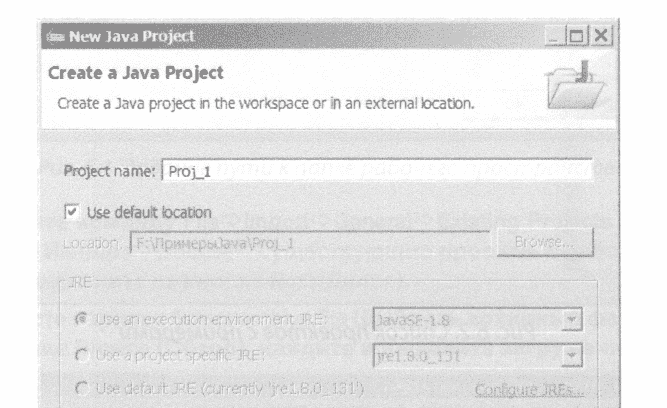

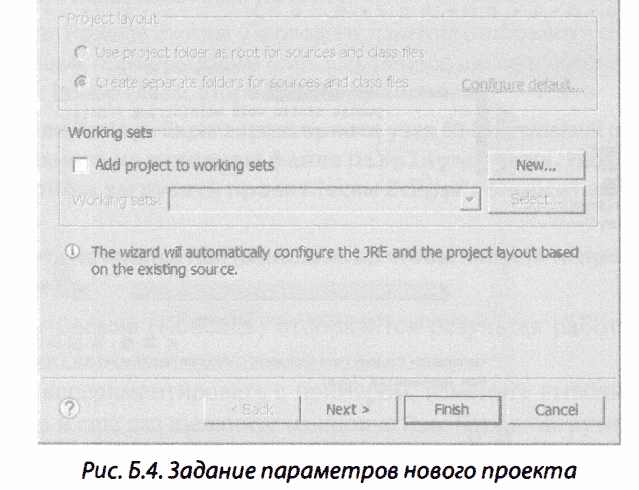

На панели Project Explorer появится пустой проект Proj_1. Теперь нужно создать в папке исходных кодов src пакет, а в пакете - класс, содержащий метод main.

Стр. 520

1. Щелкните правой кнопкой мыши на папке src и выберите в контекстном меню команду New>Package (Создать->Пакет).
2. В диалоговом окне New Java Package (Создание пакета Java) введите имя нового пакета, например Pac1, и щелкните на кнопке Finish. На левой панели в узле src появится вложенный узел Pac1.
3. Щелкните правой кнопкой мыши на узле рас1 и выберите в контекстном меню команду New->Class (Создать -Класс). Откроется диалоговое окно New Java Class (Создание класса Java), показанное на рис. Б.5.

https://www.resizepixel.com/

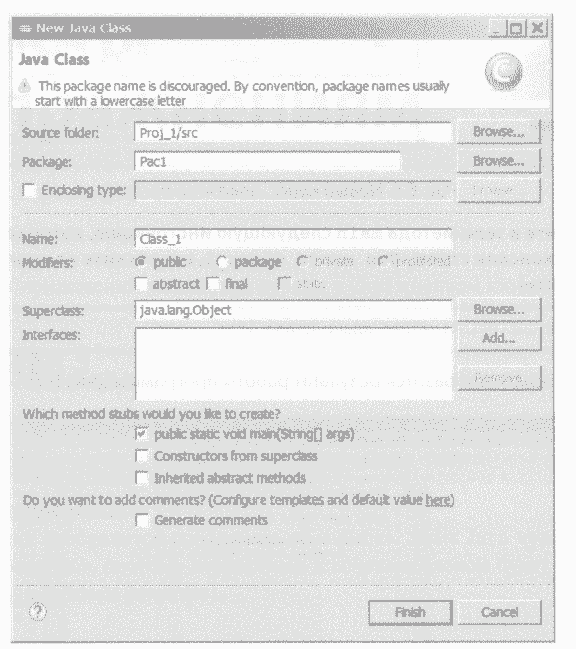

Рис. Б.5. Создание класса

1. В поле Name (Имя) введите имя класса, например Class_1.
2. Установите флажок public static void main, потому что проект должен со держать хотя бы один класс, в котором определен метод main.
3. Щелкните на кнопке Finish. В пакете Pac1 появится пустой класс Class_1 (рис. Б.6).

Стр. 521

https://www.resizepixel.com/

[figure not shown]

Рис. Б.6. Новый класс, пока что пустой

1. Введите в тело метода main следующую инструкцию, которая отображает на консоли строку Это класс Class 1, и щелкните на кнопке Run (Выполнить). System.out.println("Это класс Class 1"); На консоли отобразится результат работы программы (рис. Б.7).

https://www.resizepixel.com/

[figure not shown]

Рис. Б.7. Результат работы нового проекта

Стр. 522

# Приложение B Ответы купражнениям

В этом приложении вы найдете ответы к упражнениям книги.

# Глава 3

Унас закончились бобы! Программа отображает текст У нас закончились бобы!. Publicвместо public На экране отобразится сообщение об ошибке. Язык Java чувствителен к регистру символов, поэтому корректным ключевым словом будет public (все символы - в нижнем регистре). Mainвместо main Программа не выполняется. Начальная точка выполнения программы Java -- метод main (все символы -- в нижнем регистре). system вместо System На экране отобразится сообщение об ошибке. Язык Java чувствителен к регистру символов. Java знает, что такое System.out, поскольку этот пакет является частью библиотеки Java. Hо Java не знает, что такое system. out. Изменение отступов Код выполняется корректно, поскольку на работу Java не влияют символы разрыва строки. (Конечно, из этого правила есть исключение. Символ разрыва строки нельзя вставлять в строку символов, заключенную в двойные кавычки.) Метод print1n, включающий цифру 1 На экране отобразится сообщение об ошибке. Java не знает, что такое print1n. Отсутствующая точка с запятой На экране отобразится сообщение об ошибке. В Java нужно завершать каждую инструкцию точкой с запятой. Дополнительные точки с запятой Обычно появление дополнительной точки с запятой не приводит к какимлибо последствиям. Программа продолжает выполняться корректно. В Java необязательная точка с запятой трактуется как пустая инструкция, т.е. такая, которая не выполняет никаких действий. Поэтому ничего плохого не происходит. "Используйте прямые канычки \", а не фигурные кавычки \u201D" Программа отображает текст Используйте прямые кавычки ", а не фигурные кавычки ", который завершается фигурной кавычкой. В Java комбинация символов \" представляет прямую кавычку, а \u201D - фигурную.

# Глава 4

Добавление разделителей разрядов На экране отобразится сообщение об ошибке. В Java нельзя использовать стандартные разделители разрядов, принятые в вашей стране, для представления чисел в коде. Изменение 1000000. 00 на 1_000_000.00 Код выполняется корректно. В Java можно использовать символы подчеркивания для представления чисел в коде. amountInAccount = $50.22 На экране отобразится сообщение об ошибке. В Java нельзя использовать символы валюты для представления чисел в коде. 524 ЧАСТЬ VI Приложения

Замена всехвызовов print вызовами println

[output not shown]

```
Количество юбилеев
public class Main
{
    public static void main(String[] args)
    {
        int years;
        int anniversaries;
        years = 4;
        anniversaries = years / 4;
        System.out.println("Количество юбилеев: "+ anniversaries);
        years =  7;
        anniversaries = years     / 4;
        System.out.println("Количество юбилеев:" + anniversaries);
        years = 8;
        anniversaries = years / 4;
        System.out.println("Количество юбилеев:" + anniversaries);
    }
}
```

Стр. 525

[output not shown]

[output not shown]

Стр. 526

[output not shown]

[output not shown]

Стр. 527

# Глава 5

Делаем результат выполнения программы "Лифт" более естественным

```
public class ElevatorFitter2
{
    public static void main(String args[])
    {
        int weightOfAPerson = 150;
        int elevatorWeightLimit = 1400;
        int numberOfPeople = elevatorWeightLimit / weightOfAPerson;
        if (numberOfPeople >= 10)
        {
            System.out.println("Все члены семейства Смитов поместятся в лифт.");
        }
        else
        {
            System.out.println("Все члены семейства Смитов не поместятся в лифт.");
            System.out.println("Семейство Смитов ");
            System.out.println("в лифте.");
        }
```

Добавление третьей комбинации "имя пользователя/ пароль" в список допустимыхвариантов входа

```
import javax.swing.JOptionPane;
public class Authenticator
{
    public static void main(String args[])
    {
        String username = JOptionPane.showInputDialog ("Имя пользователя: ");
        String password = JOptionPane.showInputDialog ("Пароль: ");
        if (username != null && password != null &&
(
(username.equals ("bburd") && password.equals("swordfish"))
|| (username.equals ("hritter") && password. equals("preakston"))
|| (username.equals ("ggow") && password.equals("ihaterr"))
{
    JOptionPane.showMessageDialog(null, "Вы допущены в систему.");
}
else
{
    JOptionPane.showMessageDialog(null, "Попытайтесь еще раз…");
}
```

Стр. 528

Изменение инструкции ifmаким образом, чтобы допускать ввод имен пользователей в верхнем регистре

```
import javax.swing.JOptionPane;
public class Authenticator
{
    public static void main(String args[])
    {
        String username = JOptionPane.showInput Dialog ("Имя пользователя: ");
        String password = JOptionPane.showInputDialog("Пароль: ");
        if (username != null && password != null &&
            ( (username.equals ("bburd") ||
            username.equals ("BBURD") ) &&
            password.equals("swordfish")) ||
            ((username.equals("hritter") || username.equals("HRITTER")) && password. equals ("preakston"))
        {
            JOptionPane.showMessageDialog(null, "Вы допущены в систему.");
        }
        else
        {
            JOptionPane.showMessageDialog (null, "Попытайтесь еще pаз…");
        }
    }
}
```

Стр. 529

Замена инструкции username != null && password != null инструкцией ! (username == null | | password == null) Программа остается работоспособной, поскольку инструкция username ! = null && password != null логически эквивалентна инструкции ! (username == null || password == null). Эта эквивалентность вытекает из логического закона де Моргана. В данном случае применяется дистрибутивный закон де Моргана для операторов !, && и | |.

Замена инструкцииusername != null && password != null инструкцией ! (username == null & password == null) Программа аварийно завершается, как только пользователь щелкает на кнопке Cancel для одного из вызовов JOptionPane.showInputDialog. Причина заключается в том, что условие ! (username == null && password == null) не является логически эквивалентным условию исходной программы. Предположим, например, что пользователь ввел bburd в диалоговом окне Имя пользователя, но щелкнул на кнопке Cancel в диалоговом окне Пароль. В результате значение username будет равным bburd, а значение password --- null (в данном случае password не содержит корректного значения String). Тогда условие ! (username == null && password == null) будет равно true, поскольку это не тот случай, когда обе переменные, username и password, равны null. Итак, Java продолжает проверять значение выражения username. equals("bburd"). Затем Java переходит к проверке значения выражения password.equals("swordfish"). Но попытка вызова метода equals для переменной password приводит к аварийному завершению программы, поскольку переменная password не содержит корректного значения String. Вместо этого переменная password равна null.

Если пользователь щелкает на кнопке Cancel при вводе имени пользователя или пароля, программа отображает сообщение Недостаточно информации

```
import javax.swing.JOptionPane;
public class Authenticator
{

    public static void main(String args[])
    {
        String username = JOptionPane.showInput Dialog ("Имя пользователя: ");
        String password = JOptionPane.showInput Dialog ("Пароль: ");
        if (username == null |I password == null)
        {
            JOptionPane.showMessageDialog (null, "Недостаточно информации ");
        } else if ((username.equals("bburd") &&
                    password.equals("swordfish")) ||
                    (username.equals("hritter") &&
                    password. equals ("preakston") )
        {
        JOptionPane.showMessageDialog (null,"Вы допущены в систему.");
        }
        else
        {
            JOptionPane.showMessageDialog (null, "Попытайтесь еще раз…");
        }
    }
}
```

Стр. 530

```
Отображение количества дней в месяце. Предполагается, что в феврале всегда 28 дней
import java.util.Scanner;
public class Main
{
    public static void main(String[] args)
    {
        Scanner keyboard = new Scanner(System.in);
        System.out.print ("Укажите название месяца: ");
        String month = keyboard.next();
        int numDays = 0;
        switch (month)
        {
            case "Январь":
            case "Март":
            case "Май":
            case "Июль":
            case "Август":
            case "Октябрь"
            case "Декабрь": numDays = 31; break;
            case "Февраль": numDays = 28; break;
            case "Апрель":
            case "Июнь":
            case "Сентябрь":
            case "Ноябрь": numDays = 30; break;
        }
            System.out.print(month + ", число дней: ");
            System.out.println(numDays);
        }
    }
}
```

Стр. 531

```
Предоставьте пользователю возможность выбрать да или нетв ответ на запрос Это високосный год?
import java.util.Scanner;
public class Main
{
    public static void main(String[] args)
    {
        Scanner keyboard = new Scanner(System.in);
        System.out.print ("Укажите название месяца: ");
        String month = keyboard.next ();
        int numDays = 0;
        switch (month)
        {
            case "Январь":
            case "Март":
            case "Май":
            case "Июль":
            case "Август":
            case "Октябрь":
            case "Декабрь": numDays = 31; break;
            case "Февраль": numDays = 28; break;
            case "Апрель":
            case "Июнь":
            case "Сентябрь":
            case "Ноябрь": numDays = 30; break;
        }
        System.out.print("Это високосный год (да/нет)? ");
        String isLeapYear = keyboard.next();
        if (month.equals("Февраль") && isLeapYear.equals("да")) { numDays = 29;}
        System.out.print (month + ", число дней: ");
        System.out.println(numDays);
    }
}
```

Стр. 532

# Глава 6

```
Случайно сгенерированное число, которое находится в диапазоне от 1 до 100
import static java.lang.System.out;
import java.util.Scanner;
import java.util.Random;

public class GuessAgain
{
    public static void main(String args[])
    {
        Scanner keyboard = new Scanner(System.in) ;
        int numGuesses = 0;
        int randomNumber = new Random().nextInt (100) + 1;
        out.println(" ************ ");
        out.println("Добро пожаловать в игру!"); out.println(" ************ ");
        out.println();
        out. print ("Введите число от 1 до 100: "); int inputNumber = keyboard.nextInt (); numGuesses++;
```

```
        while (inputNumber != randomNumber)
        {
            out.println();
            if (inputNumber < randomNumber)
            {
                out.println("Попытайтесь ввести большее число…");
            }
            else
            {
                out.println("Попытайтесь ввести меньшее число…");
            }
            out.print ("Введите целое число от 1 до 100: ");
            inputNumber = keyboard.nextInt ();
            numGuesses++;
        }
        out. print ("Вы угадали после ");
        out.println(numGuesses + " попыток.");
        keyboard.close();
    }
}
```

Стр. 533

```
Отображение наибольшего числа, введенного пользователем
import java.util.Scanner;
public class Main
{
    public static void main(String[] args)
    {
        Scanner keyboard = new Scanner (System.in);
        System.out.print("Введите число (0 или отрицательное,чтобы выйти): ");
        int number = keyboard.nextInt();
        int largest = 0;
        while (number > 0)
        {
            if (number > largest){largest = number;}
            System.out.print("Введите число (0 или отрицательное, чтобы выйти): ");
            number = keyboard.nextInt();
        }
        System.out.println("Наибольшее число: " + largest);
        keyboard.close ();
    }
}
```

[output not shown]

Стр. 534

```
Подсчет факториала
import java.util.Scanner;
public class Main
{
    public static void main(String[] args)
    {
        Scanner keyboard = new Scanner (System.in) ;
        System.out. print ("Введите целое число: ");
        int n = keyboard.nextInt();
        int factorial = 1;
        for (int i = 1; i <= n; i++){factorial *= i;}
        System.out.println(n + "! pавен " + factorial);
        keyboard.close();
    }
}
```

```
Результат выполнения первого примера кода, печатающего звездочки
*****
*****
*****
*****
Результат выполнения второго примера кода, печатающего звездочки
*
**
* * *
****
*****
```

Стр. 535

```
Отображение трехкопий шаблона, состоящего из звездочек
public class Snippet
{
    public static void main(String[] args)
    {
        for (int copy = 0; copy < 3; copy++)
        {
            for (int row = 0; row < 5; row++)
            {
                for (int column = 0; column <= row; column++)
                {System.out.print ("*");}
                System.out.println();
            }
        }
    }
}
```

```
Принудительный выход из цикла
Введите значение типа int: 5
5
Введите значение типа int: 3
3
Введите значение типа int: -6
- 6
Введите значение типа int: 0 Готово!
Как работает оператор continue в цикле
Введите значение типа int: 100
Введите значение типа int: 500
Введите значение типа int: 9
Введите значение типа int: -1
-1
Введите значение типа int: 0 Готово!
```

# Будет ли код, в котором вместо цикла while используется цикл do, работать корректно?

Измененный код не будет работать корректно, поскольку он не проверяет первый пользовательский ввод. Независимо от того, что введет пользователь в качестве первого ввода, измененный код запрашивает другой ввод. Вот соответствующий пример. Введите целое число от 1 до 10: 7 Попытайтесь еще раз… Введите целое число от 1 до 10: 7 Вы выиграли после 2 попыток.

Стр. 536

# Глава 7

```
Ваш первый класс Organization
public class Organization
{
    String name;
    double revenue;
    boolean isForProfit;
}
```

```
public class Main
{
    public static void main(String[] args)
    {
        Organization orgl = new Organization();
        orgl.name = "Компания XYZ";
        orgl. revenue = 1000000.00;
        orgl.isForProfit = true;
        Organization org2 = new Organization();
        org2.name = "Университет XYZ";
        org2.revenue = 100000.00;
        org2.isForProfit = false;
        System.out.print (orgl.name);
        System.out.print(" имеет годовой доход");
        System.out.print (orgl.revenue);
        System.out.print(" и ");
        System.out.print(orgl.isForProfit ? "" : "не");
        System.out.println("коммерческая.");
        System.out.print (org2.name);
        System.out.print(" имеет годовой доход ");
        System.out.print (org2.revenue);
        System.out.print(" и ");
        System.out.print(org2.isForProfit ? "" : "не ");
        System.out.println("коммерческая.");
    }
}
```

Стр. 537

```
Ваш первый класс FoodProduct
public class FoodProduct
{
    String type;
    double weight;
    int servings;
    int calories;
}
public class Main
{
    public static void main(String[] args)
    {
        FoodProduct product1 = new FoodProduct();
        product1.type = "Кусочки персика";
        productl.weight = 500;
        product1.servings = 4;
        product1.calories = 70;
        FoodProduct product2 = new FoodProduct ();
        product2.type = "Хлеб";
        product2.weight = 500; product2.servings = 10;
        product2.calories = 150;
```

```
        System.out.print (productl.type);
        System.out.print (" весит ");
        System.out.print (productl.weight);
        System.out.print (" грамм, расфасован на ");
        System.out.print (product1.servings);
        System.out.print (" порций и содержит ");
        System.out.print (productl.calories);
        System.out.println(" калорий.");

        System.out.print (product2.type);
        System.out.print (" весит ");
        System.out.print (product2.weight);
        System.out.print (" грамм, расфасован на ");
        System.out.print (product2.servings);
        System.out.print (" порций и содержит ");
        System.out.print (product2.calories);
        System.out.println(" калорий.");
    }
}
```

```
Добавление методов displayв классы Orgainizationu FoodProduct
public class Organization
{
    String name;
    double revenue;
    boolean isForProfit;
    public void display()
    {
        System.out.print (name);
        System.out.print(" имеет годовой доход ");
        System.out.print (revenue);
        System.out.print(" и ");
        System.out.print (isForProfit ? "" : "не ");
        System.out.println("коммерческая.");
    }
}
```

```
public class Main
{
    public static void main(String[] args)
    {
        Organization orgl = new Organization();
        orgl.name = "Компания XYZ";
        orgl.revenue = 1000000.00;
        orgl.isForProfit = true;
        Organization org2 = new Organization();
        org2.name = "Университет XYZ";
        org2.revenue = 100000.00;
        org2.isForProfit = false;
        orgl.display();
        org2.display();
    }
}
```

```
public class FoodProduct
{
    String type;
    double weight;
    int servings;
    int calories;
    public void display()
    {
        System.out.print (type);
        System.out.print (" весит ");
        System.out.print (weight);
        System.out.print(" грамм, расфасованна ");
        System.out.print (servings);
        System.out.print(" порций и содержит ");
        System.out.print (calories);
        System.out.println(" калорий.");
    }
}
```

Стр. 538-539

```
public class Main
{
    public static void main(String[] args)
    {
        FoodProduct product1 = new FoodProduct();
        productl.type = "Кусочки персика "; product1.weight = 500;
        productl.servings = 4;
        product1.calories = 70;
        FoodProduct product2 = new FoodProduct();
        product2.type = "Хлеб";
        product2.weight = 500;
        product2.servings =10;
        product2.calories = 150;
        product1.display();
        product2.display();
    }
}
```

```
Подсчет суммы налогов, которые платит организация
public class Organization
{
    String name;
    double revenue;
    boolean isForProfit;
    public void display()
    {
        System.out.print (name);
        System.out.print(" имеет годовой доход ");
        System.out.print (revenue) ;
        System.out.print (", "); System.out.print(isForProfit ? "" : "не ");
        System.out.print ("коммерческая и платит ");
        System.out.print (tax()); System.out.println(" налогов.");
    }
    public double tax()
    {
        if (isForProfit) { return revenue * 0.10; }
        else { return revenue * 0.02; }
    }
}
```

Стр. 540

```
public class Main
{
    public static void main(String(] args)
    {
        Organization orgl = new Organization() ;
        orgl.name = "Компания XYZ";
        orgl.revenue = 1000000.00;
        orgl.isForProfit = true;
        Organization org2 = new Organization ();
        org2.name = "Университет XYZ";
        org2.revenue = 100000.00;
        org2.isForProfit = false;
        orgl.display();
        org2.display();
    }
}
```

```
Цена за 100 грамм, цена одной порции и общее количество калорий в продукте
public class FoodProduct
{
    String type;
    double weight;
    int servings;
    int calories;
    double cost;
    public void display()
    {
        System.out.print (type);
        System.out.print(" весит ");
        System.out.print (weight);
        System.out.print(" грамм, pасфасован на ");
        System.out.print (servings);
        System.out.print (" порций и содержит ");
        System.out.print (calories);
        System.out.println(" калорий.");
        System.out.println(" Цена за 100 грамм: " + costPer100Grams() + " " ) ;
        System.out.println(" Цена порции: " + costPerServing() + ".");
        System.out.println(" Общее количество калорий: " totalCalories() + ".");
    }
    public double costPer100Grams(){ return cost / (weight / 100);}
    public double costPerServing() { return cost / servings;}
    public int totalCalories() { return calories * servings; }
}
```

Стр. 541

```
public class Main
{
    public static void main(String[] args)
    {
        FoodProduct product1 = new FoodProduct();
        product1.type = "Кусочки персика";
        product1.weight = 500;
        product1.servings = 4;
        productl.calories = 70;
        product1.cost = 5.00;
        FoodProduct product2 = new FoodProduct();
        product2.type = "Хлеб";
        product2.weight = 500;
        product2.servings = 10;
        product2.calories = 150;
        product2.cost = 2.50;
        product1.display();
        product2.display();
    }
}
```

[output not shown]

Стр. 542

# Классы Organizationu FoodProductсзакрытыми полями и методами доступа

```
public class Organization
{
    private String name;
    private double revenue;
    private boolean isForProfit;
    public String getName() {return name;}
    public void setName(String name)
    { if (!name.equals ("")) { this.name = name;}}
    public double getRevenue() { return revenue;}
    public void setRevenue (double revenue) {if (revenue >= 0) { this.revenue = revenue; }}
    public boolean isForProfit () { return isForProfit; }
    public void setForProfit (boolean isForProfit) { this.isForProfit = isForProfit;}
}
```

Стр. 543

```
public class Main
{
    public static void main(String[] args)
    {
        Organization orgl = new Organization();
        orgl.setName ("Компания XYZ");
        orgl.setRevenue (1000000.00);
        orgl.setForProfit (true) ;
        Organization org2 = new Organization();
        org2.setName ("Университет XYZ");
        org2.setRevenue (100000.00);
        org2.setForProfit (false);
        System.out.print (orgl.getName());
        System.out.print(" имеет годовой доход ");
        System.out.print (orgl.getRevenue());
        System.out.print(" и ");
        System.out.print (orgl.isForProfit() ? "": "не ");
        System.out.println("коммерческая.");
        System.out.print (org2.getName());
        System.out.print(" имеет годовой доход ");
        System.out.print (org2.getRevenue () );
        System.out.print (" и ");
        System.out.print (org2.isForProfit() ? "" : "не ");
        System.out.print1n("коммерческая.");
    }
}
```

```
public class FoodProduct
{
    private String type;
    private double weight;
    private int servings;
    private int calories;
    public String getType() { return type;}
    public void setType(String type)
    { if (!type.equals("")) { this.type = type; } }
    public double getWeight () { return weight; }
    public void setWeight (double weight)
    { if (weight > 0) { this.weight = weight; } }
    public int getServings() { return servings; }
    public void setServings(int servings)
    { if (servings > 0) { this.servings = servings; } }

    public int getCalories() { return calories;}
    public void setCalories(int calories) { if (calories >= 0) { this.calories = calories; } }
}
```

Стр. 544

```
public class Main
{
    public static void main(String[] args)
    {
        FoodProduct product1 = new FoodProduct();
        product1.setType ("Кусочки персика");
        product1.setWeight (500);
        product1.setServings (4);
        productl.setCalories (70);
        FoodProduct product2 = new FoodProduct();
        product2.setType ("Хлеб");
        product2.setWeight (500);
        product2.setServings (10);
        product2.setCalories (150);
```

```
        System.out.print (product1.getType ());
        System.out.print(" весит ");
        System.out.print (productl.getWeight () );
        System.out.print(" грамм, расфасован на ");
        System.out.print (product1.getServings());
        System.out.print (" порций и содержит ");
        System.out.print (productl.getCalories ());
        System.out.println(" калорий.");
        System.out.print (product2.getType ());
        System.out.print (" весит ");
        System.out.print (product2.getWeight ());
        System.out.print(" грамм, pасфасован на ");
        System.out.print (product2.getServings ());
        System.out.print(" порций и содержит ");
        System.out.print (product2.getCalories ());
        System.out.println(" калорий.");
    }
}
```

Стр. 545

# После щелчка на кнопке в окне отображается сумма налогов, выплачиваемыхорганизацией

```
public class Organization
{
    String name;
    double revenue;
    boolean isForProfit;
}
import com.allmycode.dummiesframe. DummiesFrame;
```

```
public class Main
{
    public static void main(String args[])
    {
        DummiesFrame frame = new DummiesFrame("Сведения об организации");
        frame.addRow("Название");
        frame.addRow ("Годовой доход");
        frame.addRow("Коммерческая? (Y/N)");
        frame.setButtonText ("Показать");
        frame.go();
    }
    public static String calculate (String name, double revenue, String isForProfit)
    {
        Organization org = new Organization();
        org. name = name;
        org.revenue = revenue;
        double tax;
        if (isForProfit.equals ("Y")){ tax = revenue * 0.10; }
        else { tax = revenue * 0.02; }
        return "Сумма налогов: " + tax;
    }
}
```

Cтр. 546

# После щелчка на кнопке в окне отображаются цена за 100 грамм, цена за порцию и общее количество калорий в продукте

```
public class FoodProduct
{
    String type;
    double weight;
    double cost;
    int servings;
    int calories;
}
```

```
import com.allmycode.dummiesframe.DummiesFrame;
public class Main
{
    public static void main(String args[])
    {
        DummiesFrame frame = new DummiesFrame("Продукт");
        frame.addRow("Тип"); frame.addRow("Bec");
        frame.addRow("Цена");
        frame.addRow("Порций");
        frame.addRow("Количество калорий в порции");
        frame.setButtonText ("Показать");
        frame.go();
    }
```

```
    public static String calculate(
        String type, double weight, double cost, int servings, int calories)
    {
        FoodProduct product = new FoodProduct();
        product.type = type;
        product.weight = weight;
        product.cost = cost;
        product.servings = servings;
        product.calories = calories;
        return
            "Цена за 100 грамм: "
            + (cost / (weight / 100)) + "; "
            + "Цена за порцию: " + (cost / servings) + "; "
            + "Общее количество калорий: " + (calories * servings)
        ;
    }
}
```

# Глава 8

```
Ваш первый класс PlaceToLive
public class PlaceToLive
{
    private String address;
    private int number0fBedrooms;
    private double area;
    public String getAddress(){ return address; }

    public void setAddress(String address) { this.address = address; }
    public int getNumberOfBedrooms() { return numberOfBedrooms; }
    public void setNumberOfBedrooms(int numberOfBedrooms)
    { this.numberOfBedrooms = numberOfBedrooms; }
    public double getArea() { return area; }
    public void setArea(double area) { this.area = area; }
}
```

Стр. 547

```
import java.util.Scanner;
public class DisplayThePlaces
{
    public static void main(String[] args)
    {
        Scanner keyboard = new Scanner(System.in);
        PlaceToLive placel = new PlaceToLive();
        placel.setAddress("ул. Мэйн Стрит, д. 111");
        placel.setArea (600);
        placel.setNumberOfBedrooms (2);
        System.out.print("Цена " + placel.getAddress() + ": ");
        double cost1 = keyboard.nextDouble();
        PlaceToLive place2 = new PlaceToLive();
        place2.setAddress("ул. Джава Роуд, д. 222");
        place2.setArea (1000);
        place2.setNumberOfBedrooms (1);
        System.out.print("Цена " + place2.getAddress() + ": ");
        double cost2 = keyboard.nextDouble ();
        System.out.println(placel.getAddress ());
        System.out.println(" Цена за единицу площади: " + cost1 / placel.getArea());
        System.out.println(" Цена за спальню: " + cost1 / placel.getNumberOfBedrooms());
        System. out.println(place2.getAddress ());
        System.out.println(" Цена за единицу площади: " + cost2 / place2.getArea());
        System.out.println(" Цена за спальню: " + cost2 / place2.getNumberOfBedrooms());
        keyboard.close();
    }
}
```

Стр. 548

# Использование класса PlaceToLive вместе с классом Dummies Frame

```
public class PlaceToLive
{
    private String address;
    private int numberOfBedrooms;
    private double area;
    public String getAddress() { return address; }
    public void setAddress(String address) { this.address = address; }
    public int getNumberOfBedrooms() { return numberOfBedrooms; }
    public void setNumberOfBedrooms(int numberOfBedrooms)
    { this.numberOfBedrooms = numberOfBedrooms;}
    public double getArea() { return area; }
    public void setAre (double area) { this.area = area; }
}
```

```
import com.allmycode.dummiesframe.DummiesFrame;
public class Main
{
    public static void main(String args[])
    {
        DummiesFrame frame = new DummiesFrame("Жилое помещение");
        frame.addRow ("Адрес");
        frame.addRow ("Площадь");
        frame.addRow("Число спален");
        frame.addRow ("Цена");
        frame.setButtonText ("Показать");
        frame.go();
    }

    public static String calculate(
        String address,double area, int numberOfBedrooms, double cost)
    {
        PlaceToLive place = new PlaceToLive();
        place.setAddress(address);
        place. setArea (area);
        place.setNumberOfBedrooms (numberOfBedrooms);
        return address + "; "
            + "Цена за единицу площади: "
            + (cost / place.getArea()) + "; "
            + "Цена за спальню: "
            + (cost / place.getNumberOfBedrooms())
        ;
    }
}
```

Стр. 549

# Получение информации для класса PlaceToLive из дискового файла

```
public class PlaceToLive
{
    private String address;
    private int numberOfBedrooms;
    private double area;
    public String getAddress() { return address; }
    public void setAddress(String address) { this.address = address; }
    public int getNumberOfBedrooms() { return numberOfBedrooms; }
    public void setNumberOfBedrooms(int numberOfBedrooms)
    { this.numberOfBedrooms = numberOfBedrooms; }
    public double getArea() { return area; }
    public void setArea(double area) { this.area = area; }
}
```

```
import java.io.File;
import java.io.IOException;
import java.util.Scanner;

public class DisplayThePlaces
{
    public static void main(String(] args) throws I0Exception
    {
        Scanner diskScanner = new Scanner (new File("places.txt"));
        Scanner keyboard = new Scanner(System.in);
        PlaceToLive placel = new PlaceToLive();
        placel.setAddress (diskScanner.nextLine ());
        placel.setArea (diskScanner.next Double());
        placel.setNumberOfBedrooms (diskScanner.nextInt ());
        System.out.print ("Цена " + placel.getAddress() + ": ");
        double costl = keyboard.nextDouble();
        diskScanner.nextLine ();
        PlaceToLive place2 = new PlaceToLive();
        place2.setAddress (diskScanner.nextLine ());
        place2.setArea (diskScanner.next Double());
        place2.setNumberOfBedrooms(diskScanner.nextInt ());
        System.out.print("Цена " + place2.getAddress() + ": ");
        double cost2 = keyboard.nextDouble();
        System.out.println(placel.getAddress());
        System.out.printIn(" Цена за единицу площади: " + costl / placel.getArea());
        System. out.println(" Цена за спальню: " + costl/ placel.getNumberOfBedrooms());
        System.out.println (place2.getAddress());
        System.out.println (" Цена за единицу площади: " + cost2 / place2.getArea());
        System.out.println (" Цена за спальню: " + cost2 / place2.getNumberOfBedrooms());
        diskScanner.close();
        keyboard.close ();
    }
}
```

Стр. 550

```
Ниже приводится пример текстового файла places.txt:
ул. Мэйн Стрит, д. 111
1000
2
ул. Джава Роуд, д. 222
1200
3
```

Стр. 551

Создание подклассов House u Apartment

```
public class PlaceToLive
{
    private String address;
    private int numberOfBedrooms;
    private double area;
    public String getAddress() { return address; }
    public void setAddress(String address) { this.address = address; }
    public int getNumberOfBedrooms() { return numberOfBedrooms; }
    public void setNumberOfBedrooms (int numberOfBedrooms)
    { this.numberOfBedrooms = numberOfBedrooms; }
    public double getArea(){ return area;}
    public void setArea(double area) { this.area = area; }
}
```

```
public class House extends PlaceToLive
{
    private double mortgage;
    private double propertyTax;
    public double getMortgage(){ return mortgage; }
    public void setMortgage (double mortgage) { this.mortgage = mortgage; }
    public double getPropertyTax() { return propertyTax; }
    public void setPropertyTax(double propertyTax) { this.propertyTax = propertyTax; }
    public double getTotalMonthlyPayment () { return mortgage + propertyTax / 12; }
}
public class Apartment extends PlaceToLive
{
    private double rent;
    public double getRent() { return rent; }
    public void setRent (double rent) { this.rent = rent; }
}
```

Стр. 552

```
public class DisplayThePlaces
{
    public static void main(String[] args)
    {
        House placel = new House();
        placel.setAddress("ул. Мэйн Стрит, д. 111");
        placel.setArea (600) ;
        placel.setNumberOfBedrooms (2);
        placel.setMortgage (1000.00) ;
        placel.set PropertyTax(600);
        double costl = placel.getTotalMonthlyPayment();
        Apartment place2 = new Apartment ();
        place2.setAddress("ул. Джава Роуд, д. 222");
        place2.setArea (1000);
        place2.setNumberOfBedrooms(1);
        place2.setRent (1500);
        double cost2 = place2.getRent();
        System.out.println(placel.getAddress());
        System.out.println (" Цена за единицу площади: " + costl / placel.getArea());
        System.out.println (" Цена за спальню: " + cost1 / placel.getNumberOfBedrooms());
        System.out.println(place2.getAddress());
        System.out.println(" Цена за единицу площади: "+ cost2 / place2.getArea());
        System.out.println(" Цена за спальню: " + cost2 / place2.getNumberOfBedrooms());
    }
}
```

Стр. 553

Создание подклассов ProfitMakingOrganization u NonProfitOrganization

```
public class Organization_2
{
    private String name;
    private double revenue;
    public String getName(){ return name; }
    public void setName (String name)
    { if (!name. equals("")) {this.name = name;}}
    public double getRevenue() { return revenue; }
    public void setRevenue (double revenue)
    { if (revenue >= 0) { this.revenue = revenue;}}
}
```

```
public class ProfitMakingOrganization extends Organization_2
{ public double getTax(){ return getRevenue() * 0.10; } }

public class NonProfitOrganization extends Organization 2
{ public double getTax() { return getRevenue() * 0.02; } }

public class Main
{
    public static void main(String(] args)
    {
        ProfitMakingOrganization orgl = new ProfitMakingOrganization();
        orgl.setName ("Компания XYZ");
        orgl.setRevenue (1000000.00);
        NonProfitOrganization org2 = new NonProfitOrganization();
        org2.setName("Университет XYZ");
        org2.setRevenue(100000.00);
```

```
        System.out.print(orgl.getName());
        System.out.print(" имеет годовой доход ");
        System.out.print(orgl.getRevenue());
        System.out.print(" и платит ");
        System.out.print(orgl.getTax());
        System.out.printin(" в виде налогов.");
        System.out.print(org2.getName());
        System.out.print(" имеет годовой доход ");
        System.out.print(org2.getRevenue ());
        System.out.print(" и платит ");
        System.out.print(org2.getTax());
        System.out.println(" в виде налогов.");
    }
}
```

Стр. 554

Подкласс ApartmentWithFees

```
public class ApartmentWithFees extends Apartment
{
    private double fees;
    public double getFees() { return fees; }
    public void setFees(double fees) { this.fees = fees;}
    public double getTotalMonthlyPayment() { return getRent() + fees / 3; }
}
```

```
public class DisplayThePlaces
{
    public static void main(String[] args)
    {
        House placel = new House();
        placel.setAddress("ул. Мэйн Стрит, д. 111");
        placel.setArea (600);
        placel.setNumberOfBedrooms(2);
        placel.setMortgage (1000.00);
        placel.setPropertyTax (600);
        double costl = placel.getTotalMonthlyPayment();
        Apartment place2 = new Apartment();
        place2.setAddress("ул. Джава Роуд, д. 222");
        place2.setArea (1000);
        place2.setNumberOfBedrooms (1);
        place2.setRent (1500) ;
        double cost2 = place2.getRent ();
        ApartmentWithFees place3 = new ApartmentWithFees();
        place3.setAddress("ул. Фронт Стрит, д. 333");
        place3.setArea (1500) ;
        place3.setNumberOfBedrooms (2) ;
        place3.setRent (700);
        place3.set Fees (300);
        double cost3 = place3.getTotalMonthlyPayment();
        System.out.println(placel.getAddress());
        System.out.println("Месячная плата: " + costl);
        System.out.println(place2.getAddress());
        System.out.println("Месячная плата: " + cost2);
        System.out.println (place3.getAddress());
        System.out.println("Месячная плата: " + cost3);
    }
}
```

Стр. 555

# Каков результат выполнения кода MyThing?

Результат выполнения кода:

```
B MySUBThing значение равно 7
B MyOTHERThing значение равно 44
```

В программе используются следующие объявления

```
MyThing myThing, myThing2;
myThing = new MySubThing();
myThing2 = new MyOtherThing();
```

Кроме того, методы display объявлены в классаx MyThing, MySubThing и MyOtherThing. В таком случае Java вызывает методы display, которые объявлены в классах MySubThing и MyOtherThing. Даже несмотря на то что переменные myThing и myThing2 имеют тип MyThing, Java не вызывает метод display, объявленный в классе MyThing.

Стр. 556

# Глава 9

Ваш первый класс Student

```
public enum Major {КОМПЬЮТЕРНЫЕ НАУКИ, МАТЕМАТИКА, ЛИТЕРАТУРА, ФИЗИКА, ИСТОРИЯ }

public class Student
{
    private String name;
    private int id;
    private double gpa = 0.0;
    private Major major = null;
    public Student (String name, int id)
    {
        this.name = name;
        this.id = id;
        public Student (String name, int id, double gpa)
        {
            this.name = name;
            this.id = id;
            this.gpa = gpa;
        }
```

```
        public Student(String name, int id, Major major)
        {
            this.name = name;
            this.id = id;
            this. major = major;
        }
        public Student(String name, int id, double gpa, Major major)
        {
            this.name = name;
            this.id = id;
            this.gpa = gpa;
            this. major = major;
        }
        public void display()
        {
            String info = "Имя: " + name + "; ";
            info += "ID: " + id + "; ";
            info += "CБА: " + ((gpa > 0.0)?gpa: "нет") + "; ";
            info += "Специальность: " + ((major != null)?major:"нет");
            System.out.println(info);
        }
        public String getName () { return name; }
```

```
    public void setName(String name){ this.name = name; }
    public int getId(){ return id;}
    public void setId(int id){ this.id = id;}
    public double getGpa(){ return gpa;}
    public void setGpa(double gpa) { this. gpa = gpa; }
    public Major getMajor() { return major; }
    public void setMajor (Major major){ this. major = major; }
}
```

```
public class Main
{
    public static void main(String[] args)
    {
        Student student1 = new Student("Барри", 111111, 4.0, Major. КОМПЬЮТЕРНЫЕ НАУКИ);
        Student student2 = new Student("Гарриет", 222222, 3.5);
        Student student3 = new Student("Дженни", 333333,Мajor. ЛИТЕРАТУРА) ;
        Student student4 = new Student("Сэм", 444444, 3.7);
        student1.display();
        student2.display();
        student3.display();
        student4.display();
    }
}
```

Стр. 556-558

Ваш первый класс AirplaneFlight

```
public enum Airport { LHR, LAX, EWR, JFK, SFO}

import java.time.LocalTime;

public class Airplaneflight
{
    private int flightNumber;
    private Airport departureAirport;
    private LocalTime departureTime;
    private Airport arrivalAirport;
    private LocalTime arrivalTime;
```

```
    public AirplaneFlight(
        int flightNumber,
        Airport departureAirport,
        LocalTime departureTime,
        Airport arrivalAirport,
        LocalTime arrivalTime
    )
    {
        this.flightNumber = flightNumber;
        this.departureAirport = departureAirport;
        this.departureTime = departureTime;
        this.arrivalAirport = arrivalAirport;
        this.arrivalTime = arrivalTime;
    }
```

```
public AirplaneFlight(
    int flightNumber,
    Airport departureAirport,
    Airport arrivalAirport
)
{
    this.flightNumber = flightNumber;
    this.departureAirport = departureAirport;
    this.arrivalAirport = arrivalAirport;
    public void display()
    {
        String info = "Рейс: " + flightNumber + "; ";
        info += "Аэропорт вылета: " + departureAirport;
        if (departureTime != null)
        {
            info += " в " + departureTime;
            info += "; ";
            info += "Аэропорт прибытия:" + arrivalAirport; if (arrivalTime != null)
            info += " в " + arrivalTime;
            System.out.println(info);
        }
        public int getFlightNumber() { return flightNumber;}
    }
}
```

Стр. 559

```
    public void setFlightNumber(int flightNumber) { this.flightNumber = flightNumber;}
    public Airport getDepartureAirport () { return departureAirport; }
    public void setDepartureAirport (Airport departureAirport)
    { this.departureAirport = departureAirport; }
    public LocalTime getDepartureTime() { return departureTime; }
    public void setDepartureTime(LocalTime departureTime) { this.departureTime = departureTime; }
    public Airport getArrivalAirport () { return arrivalAirport; }
    public void setArrivalAirport(Airport arrivalAirport) { this.arrivalAirport = arrivalAirport; }
    public LocalTime getArrivalTime () { return arrivalTime; }
    public void setArrivalTime (LocalTime arrivalTime) { this.arrivalTime = arrivalTime; }
}
```

```
import java.time.LocalTime;

public class Main
{
    public static void main(String[] args)
    {
        AirplaneFlight flightl = new AirplaneFlight (l11, Airport.EWR, Airport.SFO);
        AirplaneFlight flight2 = new AirplaneFlight (
            222, Airport.JFK, LocalTime.of (2, 14), Airport.LAX, LocalTime.of(6, 19))
        ;
        flight1.display();
        flight2.display();
    }
}
```

Стр. 560

Класс Student, включающий метод getString

```
public enum Major { КОМПЬЮТЕРНЫЕ НАУКИ, МАТЕМАТИКА, ЛИТЕРАТУРА, ФИЗИКА, ИСТОРИЯ }
public class Student
{
    private String name;
    private int id;
    private double gpa = 0.0;
    private Major major = null;
    public Student (String name, int id)
    {
        this.name = name;
        this.id = id;
        public Student (String name, int id, double gpa)
        {
            this.name = name;
            this.id = id;
            this.gpa = gpa;
        }
    public Student (String name, int id, Major major)
    {
        this.name = name;
        this.id = id;
        this. major = major;
    }
```

```
public Student (String name, int id, double gpa, Major major)
{
    this.name = name;
    this.id = id;
    this.gpa = gpa;
    this.major = major;
    public String getString()
    {
        String info = "Имя: " + name + "; ";
        info += "ID: " + id + "; ";
        info += "СБА: " + ((gpa > 0.0)?gpa:"нет") + "; ";
        info += "Специальность: " + ((major != null)?major:"нет");
        return info;
    }
    public String getName() { return name;}
    public void setName (String name) { this.name = name;}

    public int getId(){ return id;}
    public void setId(int id) {this.id = id;}
    public double getGpa() { return gpa;}
    public void setGpa (double gpa) { this.gpa = gpa;}
    public Major getMajor() {return major;}
    public void setMajor (Major major){this. major = major;}
}
```

Стр. 561- 562

Расширение класса AirplaneFlight методом duration

```
import java.time.LocalTime;
import java.time.temporal.ChronoUnit;

public class AirplaneFlightWithDuration extends AirplaneFlight
{
    public AirplaneFlightWithDuration(
        int flightNumber,
        Airport departureAirport,
        LocalTime departureTime,
        Airport arrivalAirport,
        LocalTime arrivalTime
    )
    { super(flightNumber, departureAirport, departureTime, arrivalAirport, arrivalTime); }
    public AirplaneFlightWithDuration(int flightNumber, Airport departureAirport, Airport arrivalAirport)
    { super(flightNumber, departureAirport, arrivalAirport); }
    public long duration()
    {
        if (getArrivalTime() != null && getDepartureTime() != null)
        { return ChronoUnit. MINUTES.between(getDepartureTime(), getArrivalTime () );}
        else { return OL;}
    }
```

```
import java.time. LocalTime;
public class Main
{
    public static void main(String[] args)
    {
        AirplaneFlightWithDuration flight1 =
            new AirplaneFlightWithDuration (111, Airport.EWR, Airport.SFO);
        AirplaneFlightWithDuration flight2 =
            new AirplaneFlightWithDuration(
                222, Airport.JFK, LocalTime.of(2, 14), Airport. LAX, LocalTime.of (6, 19)
            )
        ;
        System.out.println(flightl.getString()); long duration = flightl.duration();
        if (duration != OL) { System.out.println("Длительность: " + duration + " минут.");}
        duration = flight2.duration();
        System.out.println(flight2.getString());
        if (duration != OL) { System.out.println("Длительность: " + duration + "  минут.");}
    }
}
```

Стр. 563

Класс TemperatureEvenNicer, включающий метод convertTo

```
public enum TempScale { CELSIUS, FAHRENHEIT, KELVIN, RANKINE, NEWTON, DELISLE, RÉAUMUR, ROMER, LEIDEN};
public class Temperature
{
    private double number;
    private TempScale scale;
    public Temperature()
    {
        number = 0.0;
        scale = TempScale. FAHRENHEIT;
    }
    public Temperature (double number)
    {
        this.number = number;
        scale = TempScale.FAHRENHEIT;
    }
    public Temperature (TempScale scale)
    {
        number = 0.0;
        this.scale = scale;
    }
```

```
    public Temperature (double number, TempScale scale)
    {
        this.number = number;
        this.scale = scale;
    }

    public void setNumber (double number) {this.number = number;}
    public double getNumber() { return number; }
    public void setScale (TempScale scale) {this.scale = scale;}
    public TempScale getScale() {return scale;}
    import static java.lang.System.out;
    public class TemperatureNice extends Temperature
    {
        public TemperatureNice() { super();}
        public TemperatureNice (double number){ super (number);}
        public TemperatureNice(TempScale scale) {super (scale) ;}
        public TemperatureNice(double number, TempScale scale){super (number, scale);}
        public void display() { out.printf("85.2f градусов по 8s\n", getNumber(), getScale());}
    }
```

Стр. 564

```
public class TemperatureEvenNicer extends TemperatureNice
{
    public TemperatureEvenNicer() { super(); }
    public TemperatureEvenNicer(double number) { super(number); }
    public TemperatureEvenNicer(TempScale scale) { super (scale) ; }
    public TemperatureEvenNicer(double number, TempScale scale) { super(number, scale); }
    public TemperatureEvenNicer convertTo(TempScale newScale)
    {
        double thisNumber = this.getNumber();
        TempScale thisScale = this.getScale();
        TemperatureEvenNicer temp = new TemperatureEvenNicer();
        if (thisScale == TempScale.FAHRENHEIT && newScale == TempScale.CELSIUS)
        {
            temp.setNumber((thisNumber - 32) * 5.0 / 9.0);
            temp.setScale (TempScale.CELSIUS);
        }
```

```
        else
        {
            if (thisScale == TempScale.CELSIUS && newScale == TempScale.FAHRENHEIT)
            {
                temp.setNumber(temp.getNumber() *9.0/5.0 + 32);
                temp.setScale (TempScale.CELSIUS);
            }
            else
            {
                temp.setNumber(thisNumber);
                temp.setScale(thisScale);
            }
        }
        return temp;
    }
}
```

Cтр. 565

```
public class UseTemperatureEvenNicer
{
    public static void main(String args[])
    {
        TemperatureEvenNicer temp = new TemperatureEvenNicer();
        temp.setNumber(70.0);
        temp.setScale (TempScale. FAHRENHEIT);
        temp.convertTo(TempScale.CELSIUS);
        temp.display();
        temp = new TemperatureEvenNicer(32.0);
        temp.convertTo(TempScale.CELSIUS);
        temp.display();
        temp = new TemperatureEvenNicer(TempScale.CELSIUS);
        temp.convertTo (TempScale.FAHRENHEIT);
        temp.display();
        temp = new TemperatureEvenNicer(2.73, TempScale.KELVIN);
        temp.display();
    }
}
```

Стр. 566

Среда JShellи объект типа JFrame

```
jshell>
import javax.swing.JFrame
jshell> JFrame frame
frame ==> null
jshell> frame.setSize(100, 100) I java.lang.NullPointerException thrown: at (#5:1)
jshell> frame = new JFrame()
frame ==> javax.swing. JFrame[frame0,0,0,0x0, invalid, hidden, … PaneCheckingEnabled=true]
jshell> frame.setSize(100, 100)
jshell> frame.setVisible(true)
```

В данный момент фрейм отображается на экране компьютера. В середине сеaнса вы получите исключение NullPointerException, поскольку вы пытаетесь вызвать метод frame. setSize, но не присвоили значение переменной frame. В результате переменная frame принимает значение null, поэтому вы не сможете вызвать метод.

# Замена FlowLayout на BorderLayout

Кнопка растягивается на весь фрейм. В Java используется несколько диспетчеров макетов, которые ведут себя по-разному. В классе FlowLayout размеры компонентов уменьшаются в соответствии с размерами содержащегося в них контента. В классе BorderLayout компоненты расширяются, заполняя включающий их компонент. Существуют и другие различия между диспетчерами макетов. Например, в классе FlowLayout объекты выравниваются по горизонтали. В классе BorderLayout объекты отображаются либо в центре, либо в одном из четырех углов макета.

# Глава 10

## Удаление файла Hankees.txt

Программа аварийно завершит работу. Отобразится сообщение об ошибке, в котором говорится, что файл не найден.

## Вашпервый класс MensClothingItem

```
public enum MensClothingKind {SHIRT, PANTS, JACKET, oVERCOAT, NECKTIE, SHOES}
public class MensClothingItem
{
    private MensClothingKind kind;
    private String name;
    public MensClothingItem(MensClothingKind kind, String name)
    {
        this. kind = kind;
        this.name = name;
    }

    public MensClothingKind getKind() { return kind; }
    public void setKind (MensClothingKind kind){ this.kind = kind; }
    public String getName() { return name; }
    public void setName(String name) { this.name = name; }
}
```

Стр. 567

```
import java.util.Scanner;
import java.io.File; import java.io.IOException;
import javax.swing.JFrame;
import javax.swing.JLabel;
import java.awt.GridLayout;
```

```
@SuppressWarnings("serial")
public class ClothingFrame extends JFrame
{
    public ClothingFrame()
    {
        MensClothingItem item;
        item = new MensClothingItem(MensClothingKind.SHIRT, "Дизайн #7");
        addItemInfo (item);
        item = new MensClothingItem (MensClothingKind.PANTS, "Дизайн #5");
        addItemInfo(item);
        item = new MensClothingItem (MensClothingKind. JACKET, "Дизайн #3");
        addItemInfo(item);
        item = new MensClothingItem (MensClothingKind.OVERCOAT, "Дизайн #8");
        addItemInfo(item);
        item = new MensClothingItem (MensClothingKind.NECKTIE, "Дизайн #9");
        addItemInfo(item);
        item = new MensClothingItem(MensClothingKind.SHOES, "Дизайн #4");
        addItemInfo(item);
        setTitle ("Мужская одежда");
        setLayout (new GridLayout (6, 2, 20, 3));
        setDefaultCloseOperation (EXIT ON CLOSE);
        pack();
        setVisible (true);
    }
```

```
    void addItemInfo(MensClothingItem item)
    {
        add (new JLabel(" " + item.getKind()));
        add (new JLabel (item.getName () ));
    }
    public class Main
    {
        public static void main(String[] args)
        {
            new ClothingFrame();
        }
    }
}
```

Стр. 568

Ваш первый класс PlayingCard

```
public enum Suit { ТРЕФЫ, БУБНЫ, ЧЕРВИ, ПИКИ }
public class PlayingCard
{
    private Suit suit;
    private int number;

    public PlayingCard(Suit suit, int number)
    {
        this.suit = suit;
        this.number = number;
    }
```

```
    public String getString()
    {
        String numberString;
        switch (number)
        {
            case 11: numberString = "Валет"; break;
            case 12: numberString = "Дама"; break;
            case 13: numberString = "Король"; break;
            case 1: numberString = "Туз"; break;
            default: numberString = Integer.toString(number); break;
        }
        return numberString + suit;
    }
    public Suit getSuit(){ return suit;}
    public void setSuit (Suit suit) { this.suit = suit;}
    public int getNumber() { return number;}
    public void setNumber(int number) { this.number = number;}
}
```

Стр. 569

[output not shown]

# Подкласс MensClothingItemс методами designer, coloru cost

```
import java.awt.Color;
public class MensClothingItemPlus extends MensClothingItem
{
    public static String designer = "Дом моды для чайников";
    private Color color;
    private double cost;
    public MensClothingItemPlus (
        MensClothingKind kind,
        String name,
        Color color,
        double cost
    )
    {
```

Стр. 570

```
        super(kind, name);
        this.color = color;
        this.cost = cost;
    }
    public Color getColor() { return color; }
    public void setColor (Color color) { this.color = color; }
    public double getCost () { return cost; }
    public void setCost (double cost) { this.cost = cost; }
}
```

```
import java.awt.Color;
import java.awt.GridLayout;
import javax.swing.JFrame;
import javax.swing.JLabel;

@SuppressWarnings ("serial")
public class ClothingFrame extends JFrame
{
    public ClothingFrame()
    {
        MensClothingItemPlus item;
        add(new JLabel (MensClothingItemPlus.designer));
        add (new JLabel (" "));
        add (new JLabel (" "));
        add(new JLabel(" "));
        double totalCost = 0;
```

```
    item = new MensClothingItemPlus (MensClothingKind.SHIRT, "Дизайн #7", Color.GRAY, 50.00);
        addItemInfo(item);
        totalCost += item.getCost ();
        item = new MensClothingItemPlus (MensClothingKind. PANTS, "Дизайн #5", Color.BLACK, 70.00);
        addItemInfo(item);
        totalCost += item.getCost();
        item = new MensClothingItemPlus(MensClothingKind.JACKET, "Дизайн #3", Color.BLACK, 70.00);
        addItemInfo(item);

        totalCost += item.getCost ();
        item = new MensClothingItemPlus(MensClothingKind.OVERCOAT, "Дизайн #8", Color.GRAY, 100.00);
        addItemInfo (item);
        totalCost += item.getCost ();
        item = new MensClothingItemPlus(MensClothingKind.NECKTIE, "Дизайн #9", Color.BLUE, 30.00);
        addItemInfo(item);
        totalCost += item.getCost();
        item = new MensClothingItemPlus(MensClothingKind.SHOES, "Дизайн #4", Color.DARK GRAY, 80.00);
        addItemInfo(item) ;
        totalCost += item.getCost ();
```

```
        add(new JLabel(" "));
        add (new JLabel (" "));
        add (new JLabel (" "));
        add(new JLabel (Double.toString (totalCost)));
        setTitle ("Мужская одежда");
        setLayout (new GridLayout (8, 4, 20, 3));
        setDefaultCloseOperation (EXIT ON CLOSE);
        pack();
        setVisible (true) ;
    }
    void addItemInfo(MensClothingItemPlus item)
    {
        add(new JLabel(" " + item.getKind()));
        add (new JLabel (item.getName () ));
        add(new JLabel(item.getColor().toString()));
        add(new JLabel (Double.toString (item.getCost())));
    }
}
```

Стр. 571

# Подсчет количества игральных карт

```
public class PlayingCardPlus extends PlayingCard
{
    public static int count = 0;
    public PlayingCardPlus (Suit suit, int number)
    {
        super(suit, number);
        count++;
    }
    public class Main
    {
        public static void main(String[] args)
        {
            PlayingCardPlus cardl = new PlayingCardPlus (Suit.ПИКИ, 13);
            PlayingCardPlus card2 = new PlayingCardPlus (Suit.ЧЕРВИ, 1);
            PlayingCardPlus card3 = new PlayingCardPlus (Suit.БУБНЫ, 3);
            System.out.println(cardl.getString());
            System.out.println(card2.getString());
            System.out.println(card3.getString());
            System.out.println("Количество карт: "+ PlayingCardPlus.count);
    }
}
```

Стр. 572

Каков результат выполнения кода MutableInteger?

```
bigValue: 1000000
holder1: 42
holder2: 7
bigValue: 1000001
holder1: 43
holder2: 8
bigValue в соответствии с holder1: 1000002
bigValue в соответствии с holder2: 1000002
```

Каков результат выполнения кода Main1?

```
Джордж
Барри
```

Первый вызов println отображает статическую переменную name, относящуюся к классу Main1; второй вызов println отображает переменную name, которая является локальной для метода main. Стр. 573

Каков результат выполнения кода Main2?

```
Джордж
Барри
Джордж
```

Выражение this.name ссылается на поле name (переменная, принадлежащая этому экземпляру класса Main2). Каков результат выполнения кода Main3?

```
Леонард
Джордж
```

Первый вызов println отображает переменную name, которая является локальной для конструктора OtherClass. Второй вызов println отображает статическое поле name, которое относится к классу Main3. Каков результат выполнения кода Main4?

```
Леонард
Джордж
```

Первый вызов println ссылается на переменную name, которая является локальной для конструктора YetAnotherClass. Второй вызов println ссылается на поле name, которое относится к объекту whoCreatedMe (экземпляр класса Main4).

# Глава 11

Фрейм, в котором отображается количество постояльцев в комнате

```
import com.allmycode.dummiesframe.DummiesFrame;
public class Main
{
    public static void main(String args[])
    {
        DummiesFrame frame = new DummiesFrame("Отель");
        frame.addRow("Номер комнаты");
        frame.setButtonText ("Количество постояльцев в комнате");
        frame.go();
    }
    public static int calculate(int room)
    {
        int guests[] = {1, 4, 2, 0, 2, 1, 4, 3, 0, 2);
        return guests[room];
    }
}
```

Стр. 574

Средняя величина значений в массиве

```
public class Main
{
    public static void main(String[] args)
    {
        double[] values = (3.4, 5.7, 9.8, 0.0, 10.1);
        double total = 0;
        for (double value : values) { total += value; }
        System.out.println(total / values.length) ;
    }
}
```

Размещение заданного числа постояльцев в свободной комнате отеля

```
import java.io.File;
import java.io.IOException;
import java.io. PrintStream;
import java.util.Scanner;
import javax.swing.JOptionPane;
import com.allmycode.dummiesframe.DummiesFrame;
```

```
public class FindVacancy
{
    static int guests[] = new int[10];
    static int roomNum;
    public static void main(String args[]) throws IOException
    {
        Scanner diskScanner = new Scanner(new File("GuestList.txt"));
        for (roomNum = 0; roomNum < 10; roomNum++)
        { guests[roomNum] = diskScanner.nextInt(); }
        diskScanner.close ();

        roomNum = 0;
        while (roomNum < 10 && guests[roomNum] != 0) { roomNum++; }
        if(roomNum == 10)
        { JOptionPane.showMessageDialog (null,"Извините, свободных комнат нет"); }
        else
        {
            DummiesFrame frame = new DummiesFrame ("Свободные места");
            frame.addRow("Сколько человек поселятся в комнате " + roomNum + "?");
            frame.setButtonText ("Отправить");
            frame.go();
        }
    }
```

```
    public static String calculate(int numberOfPeople) throws IOException
    {
        guests[roomNum] = numberOfPeople;
        String displayText = numberOfPeople +"мест забронировано в комнате "+roomNum;
        PrintStream listOut = new PrintStream("GuestList.txt");
        for (roomNum = 0; roomNum < 10; roomNum++)
        {
            listOut.print (guests [roomNum]);
            listOut.print(" ");
        }
        listOut.close();
        return displayText;
    }
}
```

Стр. 575

Поиск среднего бала аттестата студента (СБА)

```
public enum Major { КОМПЬЮТЕРНЫЕ НАУКИ, МАТЕМАТИКА, ЛИТЕРАТУРА, ФИЗИКА, ИСТОРИЯ }
public class Student
{
    private String name;
    private int id;
    private Major major = null;
    private double[] grades;
    public Student(String name, int id)
    {
        this.name = name;
        this.id = id;
    }
    public Student(String name, int id, Major major)
    {
        this.name = name;
        this.id = id;
        this.major = major;
    }
```

```
    public Student(String name, int id, Major major, double[] grades)
    {
        this.name = name;
        this.id = id;
        this.major = major;
        this.grades = grades;
    }
    public String getInfo()
    {
        String info = "Имя: " + name + "; ";
        info += "ID: " + id + "; ";
        info += "Специальность: " + (((major != null)?major:"нет") - "; ");
        info += "СБА: " + calculateGpa();
        return info;
    }
```

```
    private double calculateGpa()
    {
        double total = 0.0;
        for (double grade : grades) { total += grade;}
        System.out.println(total);
        System.out.println(grades.length);
        return total / grades.length;
    }
    public String getName(){ return name; }
    public void setName(String name) { this.name = name; }
    public int getId() { return id; }
    public void setId(int id) { this.id = id; }
    public Major getMajor() { return major; }
    public void setMajor(Major major) { this.major = major; }
    public double[] getGrades() { return grades; }
    public void setGrades(double[] grades) { this.grades = grades; }
}
```

```
public class Main
{
    public static void main(String[] args)
    {
        double gradesl[] = (4.0, 3.5, 2.5, 4.0, 3.0};
        Student student1 = new Student ("Барри", 111111, Major.КОМПЬЮТЕРНЫЕ_НАУКИ, grades1);
        double grades2[] = {3.5, 3.3, 2.5, 4.0, 3.1};
        Student student2 = new Student ("Гарриет", 222222, Major.MATEMАТИКА, grades2);
        double grades3[] = {3.0, 2.0, 2.5, 4.0, 4.0};
        Student student3 = new Student ("Дженни", 333333, Major. ЛИТЕРАТУРА, grades3);
        double grades4[] = {2.8, 3.8, 4.0, 3.5, 3.5};
        Student student4 = new Student("Сэм", 444444, Major. ФИЗИКА, grades4);
        System.out.println(student1.getInfo());
        System.out.println(student2.getInfo());
        System.out.println(student3.getInfo());
        System.out.println(student4.getInfo());
    }
}
```

Стр. 576- 577

Простой текстовый редактор

```
import static java.lang.System.out;
import java.util.Scanner;
public class Editor
{
    public static void main(String[] args)
    {
        final int NUM LINES = 5;
        Scanner keyboard = new Scanner (System. in);
        String[] lines = {"""};
        while (true)
        {
            out.println();
            for (String line : lines) { out.println("> " + line); }
            out.println();
            int lineToReplace = 0;
            do {
                out.print ("Строка для замены (или -1 для выхода): ");
                lineToReplace = keyboard.nextInt ();
                keyboard.nextLine();
            } while (lineToReplace < -1 || lineToReplace >= NUM LINES);
            if (lineToReplace == -1){ break; }
            out.print("Введите новую строку: ");
            lines[lineToReplace] = keyboard.nextLine();
        }
        keyboard.close();
    }
}
```

Стр. 578

Наибольшее из трехзначений int

```
public class Main
{
    public static void main(String[] args)
    {
        if (args.length < 3) { System.out.println("Использование: java Main intValuel intValue2 intValue3"); }
        else
        {
            int largest = Integer.parseInt (args[0]);
            int next = Integer.parseInt(args[1]);
            if (next > largest) { largest = next; }
            next = Integer.parseInt (args[2]);
            if (next > largest) { largest = next; }
            System.out.println(largest);
        }
    }
}
```

Стр. 579

Текстовый редактор со входным и выходным файлами

```
import static java.lang.System.out;
import java.io.File;
import java.io.FileNotFoundException;
import java.io. PrintStream;
import java.util.Scanner;
```

```
public class Editor
{
    public static void main(String[] args) throws FileNotFoundException
    {
        final int NUM LINES = 5;
        Scanner keyboard = new Scanner(System.in);
        String[] lines = ( "", "", "", "", "" };
        Scanner fileIn = new Scanner (new File(args[0]));
        for (int i = 0; i < 5; i++) { lines[i] = fileIn.nextLine(); }
```

```
        while (true)
        {
            out.println();
            for (String line : lines) { out.println("> " + line); }
            out. println();
            int lineToReplace = 0;
            do
            {
                out.print("Строка для замены (или -1 для выхода): ");
                lineToReplace = keyboard.nextInt ();
                keyboard.nextLine ();
            } while (lineToReplace < -1 || lineToReplace >= NUMLINES);
            if (lineToReplace == -1) { break; }
            out.print ("Введите новую строку: ");
            lines[lineToReplace] = keyboard.nextLine();
        }
```

```
        PrintStream fileOut = new PrintStream(args[1]);
        for (int i = 0; i < 5; i++) { fileOut.println(lines[i]); }
        keyboard.close();
        fileIn.close();
        fileOut.close ();
    }
}
```

Стр. 580

# Глава 12

Наибольшее значение в коллекции ArrayList

```
import java.util. ArrayList;
public class Main
{
    public static void main(String[] args)
    {
        ArrayList list = new ArrayList<>();
        list.add (85);
        list.add (19);
        list.add(0);
        list.add(103);
        list.add(13);
        int largest = Integer.MIN VALUE;
        for (Integer i : list)
        { if (i > largest) { largest = i; } }
        System.out.println(largest);
    }
}
```

Вставка слова в коллекцию ArrayList

```
import java.util.ArrayList;
import java.util.Scanner;
public class Main
{
    public static void main(String(] args)
    {
        ArrayList words = new ArrayList<>();
        words.add("зебра");
        words.add(" кошка");
        words.add("лошадь");
        words.add("собака");
        Scanner keyboard = new Scanner(System.in);
        String newWord = keyboard.next();
        int i = 0;
        while(
            newWord.compareToIgnoreCase (words.get (i)) > 0
            && i < words.size()
        )
        {
            i++;
            words.add(i, newWord);
            for (String string : words) { System.out.print1n(string); }
            keyboard.close();
        }
    }
}
```

Стр. 581

Текстовый редактор, сохраняющий строки в коллекции ArrayList

```
import static java.lang.System.out;
import java.util.ArrayList;
import java.util.Scanner;
```

```
public class Editor
{
    public static void main(String[] args)
    {
        Scanner keyboard = new Scanner(System.in);
        ArrayList lines = new ArrayList<>();
        String command = "";
        while (!command.equals("q"))
        {
            out.println();
            for (int i = 0; i < lines.size(); i++) { out.println(i + ": " + lines.get(i)); }
```

```
            out.println();
            int lineNumber = 0;
            out.print("Команда (i #, r #, d #, q): ");
            command = keyboard.next();
            if (! command.equals("q"))
            {
                lineNumber = keyboard.nextInt(); keyboard.nextLine();
                System.out.println(command + " " + lineNumber);
                switch (command)
                {
                    case "i":
                        out. print("Введите новую строку: ");
                        while (lineNumber > lines.size()) { lines.add("");}
                        lines.add(lineNumber, keyboard.nextLine());
                        break;
                    case "r":
```

```
                        out.print("Введите новую строку: ");
                        lines.set (lineNumber, keyboard.nextLine()); break;
                    case "d":
                        lines.remove (lineNumber);
                }
            }
        }
        keyboard.close();
    }
}
```

Стр. 582

Выплата бонусов сотрудникам

```
import java.text.NumberFormat;
import java.util. ArrayList;
public class Bonuses
{
    public static void main(String[] args)
    {
        ArrayList employees = new ArrayList<>();
        NumberFormat currency = NumberFormat.getCurrencyInstance();
        fillTheList (employees);
        double total = employees.stream()
            .filter((employee) -> employee.getScore() >= 3)
            .map((employee) -> 100.00)
            .reduce (0.0, (bonusl, bonus2) -> bonusl + bonus2)
        ;
        System.out.println(currency.format (total));
    }
    static void fillTheList (ArrayList employees)
    {
        employees.add(new Employee("Барри", 2));
        employees.add (new Employee("Гарриет", 3));
        employees.add (new Employee ("Дженни", 5));
        employees.add (new Employee ("Сэм", 5));
    }
}
```

Стр. 583

Среднее время приготовления вегетарианских блюд

```
import java.util.ArrayList;
public class Recipes
{
    public static void main(String[] args)
    {
        ArrayList recipes = new ArrayList<>();
        fillTheList (recipes);
        int total = recipes.stream()
            .filter((recipe) -> recipe.isVegetarian())
            .map((recipe) -> recipe.getTime ())
            .reduce(0, (timel, time2) -> timel + time2)
        ;
        int count = recipes.stream()
            .filter((recipe) -> recipe.isVegetarian())
            .map((recipe) -> 1)
            .reduce (0, (valuel, value2) -> valuel + value2)
        ;
        System.out.println(total / (double) count);
    }
```

```
    static void fillTheList (ArrayList recipes)
    {
        ArrayList ingredients = new ArrayList<>();
        ingredients.add(Ingredient.BEEF);
        ingredients.add(Ingredient.HAM);
        ingredients.add (Ingredient.APPLES);
        recipes.add(new Recipe("Рецепт 1", ingredients, 100));
        ingredients = new ArrayList<>();
        ingredients.add(Ingredient.PEAS);
        ingredients.add(Ingredient.CARROTS);
        recipes.add(new Recipe("Рецепт 2", ingredients, 200));
        ingredients = new ArrayList<>();
        ingredients.add (Ingredient.PEAS);
        ingredients.add(Ingredient.APPLES);
        recipes.add(new Recipe("Рецепт 3", ingredients, 300));
    }
}
```

Стр. 584

# Глава 13

Добавление блока try catchво избежание аварийного завершения кода

```
import java.util.Scanner;
public class Main
{
    public static void main(String[] args)
    {
        Scanner keyboard = new Scanner(System.in);
        String[] words = new String[5];
```

```
        int i = 0;
        try {
            do
            {
                words[i] = keyboard.next();
            } while (!words[i++].equals("Выход"));
        }
        catch (ArrayIndexOutOfBoundsException e)
        { System.out.println("Можно ввести максимум пять слов"); }
        for (int j = 0; j < 5; j++)
        {
            try { System.out.println(words[j].length()); }
            catch (NullPointerException e)
            { System.out.println("Можно ввести до пяти слов"); }
        }
        keyboard.close();
    }
}
```

Чтение значений, вводимыхпользователем

```
import static java.lang.System.out;
import java.util.Scanner;
import java.text.NumberFormat;
public class InventoryD
{
    public static void main(String args[])
    {
        Scanner keyboard = new Scanner(System.in);
        NumberFormat currency = NumberFormat.getCurrencyInstance();
        try
        {
            out.print ("Какова цена за коробку? ");
            String boxPriceIn = keyboard.next();
            double boxPrice = Double.parseDouble (boxPriceIn);
            if (boxPrice <= 0.0) { throw new OutOfRangeException(boxPriceIn); }
            out. print ("Каково максимальное число коробок? ");
            String maxBoxesIn = keyboard.next();
            int maxBoxes = Integer.parseInt (maxBoxesIn);
            if(maxBoxes <= 0) { throw new OutOfRangeException(maxBoxesIn); }
            out.print ("Сколько коробок вы насчитали? ");
            String numBoxesIn = keyboard.next ();
            int numBoxes = Integer.parseInt (numBoxesIn);
            if (numBoxes <0) { throw new OutOfRangeException(numBoxesIn); }
            if (numBoxes > maxBoxes) { throw new NumberTooLargeException (numBoxesIn); }
            out.print ("Общая стоимость равна: ");
            out.println(currency.format (numBoxes * boxPrice));
        }
```

```
        catch (NumberFormatException e)
        {
            out.print (e.getMessage());
            out.println(" Невозможно преобразовать строку в число.");
        }
        catch (OutOfRangeException e)
        {
            out.print (e.getValue ());
            out.println("? Это невозможно!");
        }
        catch (Exception e)
        {
            out.print ("Что-то здесь не так, ");
            out.print("но что именно, непонятно.");
            out.println("Тип исключения неизвестен.");
        }
        out.println("Вышли из блоков try-catch.");
        keyboard.close ();
    }
}
```

Стр. 585 - 586

Обработка исключений, включая неподтвержденное исключение FileNotFoundException

```
import java.io.File;
import java.io.FileNotFoundException;
import java.util.InputMismatchException;
import java.util.Scanner;
public class Main
{
    public static void main(String[] args)
    {
        Scanner diskScanner = null;
        try
        {
            diskScanner = new Scanner(new File("numbers.txt"));

        }
```

```
        catch (FileNotFoundException e) { e.printStackTrace(); }
        int[] numerators = new int[5];
        int[] denominators = new int [5];
        int i = 0;
        while (diskScanner.hasNextInt())
        {
            try
            {
                numerators[i] = diskScanner.nextInt ();
                denominators[i) = diskScanner.nextInt ();
            }
            catch (IndexOutOfBoundsException e)
            {System.out.println( "Индекс массива " + i + " выходит за допустимые границы.");}
            catch (InputMismatchException e)
            { System.out.println("Попытка чтения значения, которое не является целым.");}
            i++;
        }
```

```
        for (int j = 0; j < numerators.length; j++)
        {
            try { System.out.println(numerators[j] / denominators[j]); }
            catch (ArithmeticException e) { System.out.println("Деление на 0 индекса массива " + i); }
        }
        diskScanner.close();
    }
}
```

Стр. 587

Исправление некорректногокода, работающего собъектами DataInputStreamu DataOutputStream

```
import java.io. DataInputStream;
import java.io. DataOutputStream;
import java.io.EOFException;
import java.io.File;
import java.io.FileInputStream;
import java.io.FileNotFoundException;
import java.io.FileOutputStream;
import java.io.IOException;
public class Main
{
    public static void main(String[] args)
    {
        File fileIn = new File("input");
```

```
        FileInputStream fileInStrm = null;
        try { fileInStrm = new FileInputStream(fileIn); }
        catch (FileNotFoundException el) { el.printStackTrace (); }
        DataInputStream dataInStrm = new DataInputStream(fileInStrm);

        File fileOut = new File("output");
        FileOutputStream fileOutStrm = null;
        try { fileOutStrm = new FileOutputStream(fileOut); }
        catch (FileNotFoundException el) { el.printStackTrace(); }
        DataOutputStream dataOutStrm = new DataOutputStream(fileOutStrm);

        int numFilesCopied = 0;
        try { while (true) { dataOutStrm.writeByte (dataInStrm.readByte()); } }
        catch (EOFException e) { numFilesCopied = 1; }
        catch (IOException e) { e. printStackTrace (); }
        catch (NullPointerException e) { e. printStackTrace (); }
        System.out.println("Количество скопированных файлов: " + numFilesCopied);
    }
}
```

Стр. 588

Добавление вызовов closeв блоки finally

```
import java.io. DataInputStream;
import java.io. DataOutputStream;
import java.io.EOFException;
import java.io. File;
import java.io.FileInputStream;
import java.io. FileOutputStream;
import java.io.IOException;
public class Main
{
    public static void main(String[] args) throws Exception
    {
        int numFilesCopied = 0;
```

```
        File fileIn = new File("input");
        FileInputStream fileInStrm = new FileInputStream(fileIn);
        File fileOut = new File("output");
        FileOutputStream fileOutStrm = new FileOutputStream(fileOut);
        DataInputStream dataInStrm = null;
        DataOutputStream dataOutStrm = null;
        // блин Барри, твой говнокод просто безграничен
        try {
            dataInStrm = new DataInputStream(fileInStrm);
            dataOutStrm = new DataOutputStream(fileOutStrm);
                try { while (true) { dataOutStrm.writeByte (dataInStrm.readByte()); } }
            catch (EOFException e) { numFilesCopied = 1; }
        }
        catch (IOException e){ e.printStackTrace(); }
        // finally то зачем, ну не пишут так...
        finally
        {
            dataInStrm.close ();
            dataOutStrm.close();
        }
        System.out.println("Число скопированных файлов: " numFilesCopied);
    }
}
```

Стр. 589

Использование инструкции tryпри работе с ресурсами

```
import java.io. DataInputStream;
import java.io. DataOutputStream;
import java.io.EOFException;
import java.io.File;
import java.io.FileInputStream;
import java.io.FileOutputStream;
import java.io.IOException;
public class Main3
{
    public static void main(String[] args) throws Exception
    {
        int numFilesCopied = 0;
        File fileIn = new File("input");
        FileInputStream fileInStrm = new FileInputStream(fileIn);
        File fileOut = new File("output");
        FileOutputStream fileOutStrm = new FileOutputStream(fileOut);
        try (
            DataInputStream dataInStrm = new ataInputStream(fileInStrm);
            DataOutputStream dataOutStrm = new DataOutputStream(fileOutStrm)
        )
        {
            try { while (true) { dataOutStrm.writeByte (dataInStrm.readByte()); }
            catch (EOFException e) {numFilesCopied = 1;}
        }
        catch (IOException e) { e. printStackTrace(); }
        System.out.println("Число скопированных файлов: " + numFilesCopied) ;
    }
}
```

# Глава 14

Добавление методов доступа в класс SomeClass

```
class SomeClass
{
    private int myField = 10;
    public int getMyField() { return myField;
    public void setMyField(int myField) { this.myField = myField;}
}
class Some0therClass
{
    public static void main(String args[])
    {
        SomeClass someObject = new SomeClass();
        System.out.println (someObject.getMyField());
    }
}
```

Стр. 590

Создание фрейма, отображающегозеленый, желтый и красный сигналы светофора

```
package com. burdbrain.drawings;
import java.awt.Color;
import java.awt.Graphics;
public class Drawing
{
    public int x = 40, y = 40, width = 40, height = 40;
    enum State { gReeN, YelloW, REDЪ
```

```
    State state = State.GREEN;
    public void paint (Graphics g)
    {
        switch (state)
        {
            case GREEN:
                showGreen (g, false);
                showYellow(g, true);
                state = State.YELLOW;
                break;
            case YELLOW:
                showYellow(g, false);
                showRed(g, true) ;
                state = State.RED;
                break;
            case RED:
                showRed(g, false);
                showGreen (g, true);
                state = State. GREEN; break;
        }
    }
```

```
    void showGreen (Graphics g, boolean t)
    {
        g.setColor(t ? Color.GREEN : Color.WHITE);
        g.fill0val(x, y + 100, width, height);
    }
    void showYellow(Graphics g, boolean t)
    {
        g.setColor(t ? Color.YELLOW : Color.WHITE);
        g.fill0val (x, y + 50, width, height);
    }
    void showRed(Graphics g, boolean t)
    {
        g.setColor(t ? Color.RED : Color.WHITE);
        g.fill0val(x, y, width, height);
    }
}
```

Стр. 591

```
package com.burdbrain.frames;
import java.awt. Graphics;
import javax.swing.JFrame;
import com.burdbrain.drawings.Drawing;

public class ArtFrame extends JFrame
{
    private static final long serialVersionUID = 1L;
    Drawing drawing;
    public ArtFrame (Drawing drawing)
    {
        this.drawing = drawing;
        setTitle("Абстрактное искусство");
        setDefaultCloseOperation(EXIT ON CLOSE);
    }
    public void paint (Graphics g) { drawing.paint (g); }
}
```

```
import com.burdbrain.drawings.Drawing;
import com.burdbrain.frames.ArtFrame;
class ShowFrame
{
    public static void main(String args[])
    {
        ArtFrame artFrame = new ArtFrame (new Drawing());
        artFrame.setSize (60, 200);
        artFrame.setVisible(true) ;
        while (true)
        {
            try
            {
                Thread.sleep (10000) ;
                art Frame.repaint ();
            }
            catch (InterruptedException e) { e.printStackTrace (); }
        }
     }
 }
```

Стр. 592

Книги и авторы

```
public class Book
{
    private String title;
    private Author author;
    public Book(String title, Author author)
    {
        this.title = title;
        this.author = author;
    }
    public String getTitle() { return title; }
    public void setTitle(String title) { this.title = title; }
    public Author getAuthor() { return author; }
    public void setAuthor (Author author) { this.author = author; }
}
```

```
import java.util. ArrayList;
public class Author
{
    private String name;
    private ArrayList books = new ArrayList<>();
    public Author(String name) { this.name = name; }
    public void display()
    {
        System.out.println(name);
        for (Book book : books)
        { System.out.println(book.getTitle());}
    }
    public String getName() { return name; }
    public void setName(String name) {this.name = name; }
    public ArrayList getBooks() { return books;}
    public void setBooks(ArrayList books) { this.books = books;}
}
```

Стр. 593

```
public class Main
{
    public static void main(String[] args)
    {
        Author dickens = new Author("Чарльз Диккенс");
        Book greatExpectations = new Book("Большие надежды", dickens);
        Book taleOfTwoCities = new Book("Повесть о двух городах", dickens);
        dickens.getBooks().add(greatExpectations);
        dickens.getBooks().add(taleOfTwoCities);
        dickens.display();
    }
}
```

Песни, альбомы, исполнители и плейлисты

```
public enum Genre { ROCK, POP, BLUES, CLASSICAL }
import java.util. ArrayList;
public class Artist
{
    private String name;
    private ArrayList items = new ArrayList<>();
    public Artist (String name)
    {
        super();
        this.name = name;
    }
    public String getString(){ return name;}
    public String getName(){ return name;}
    public void setName(String name) {this.name = name;}
    public ArrayList getItems() { return items;
    public void add(Item item){ items.add(item);
}
```

Стр. 594

```
public class Item
{
    private String name;
    private Artist artist;
    public Item(String name, Artist artist)
    {
        this.name = name;
        this.artist = artist;
    }
    public String getString() { return name + ", " + artist.getString() + "\n"; }
    public String getName() { return name; }
    public void setName(String name) { this.name = name; }
    public Artist getArtist () { return artist; }
    public void setArtist(Artist artist) { this.artist = artist; }
    public String toString() { return (name + " " + artist.getName()); }
}
```

Стр. 595

```
public class Song extends Item
{
    private Genre genre;
    public Song(String name, Artist artist, Genre genre)
    {
        super(name, artist);
        this.genre = genre;
    }
    public String getString(){ return getName() + ", "+ getArtist().getString() + ", genre + "\n"; }
    public Genre getGenre () { return genre;}
    public void setGenre (Genre genre) this.genre = genre;}
    @Override
    public String toString()
    {
        String string = super.toString() + " "
        string += genre;
        return string;
    }
}
```

```
import java.util. ArrayList;
public class Album extends Item
{
    private ArrayList songs = new ArrayList<>();
    public Album(String name, Artist artist) { super (name, artist); }
    public String getString()
    {
        String string = getName() + "\n";
        for (Song song : songs) { string += " " + song.getString();}
        return string;
    }
    public ArrayList getSongs(){ return songs;}
    public void add(Song song){ songs.add(song);}
    @Override
    public String toString()
    {
        String string = super.toString() + " ";
        for (Song song : songs) { string += song.toString() + " ";}
        return string;
    }
}
```

Стр. 596

```
import java.util.ArrayList;
public class Playlist
{
    private ArrayList items = new ArrayList<>();
    public String getString()
    {
        String string = "";
        for (Item item : items) { string += item.getString();}
        return string;
    }
    public void addItem (Item item){ items.add (item);}
    public ArrayList getItems(){ return items;}
    public void setItems(ArrayList items) { this.items = items; }
}
```

Стр. 597

```
public class SongsAndAlbumsTest
{
    public static void main(String[] args)
    {
        Artist john = new Artist ("Элтон Джон");
        Item rocketMan = new Item("Rocket Man", john);
        Artist bach = new Artist ("И. С. Баx");
        Song wellTemperedClavier = new Song("Хорошо темперированный клавир", bach, Genre.CLASSICAL) ;
        bach.add(wellTemperedClavier);
        Song tocataAndFugue = new Song("Токката и фуra", bach, Genre.CLASSICAL);
        bach.add(tocataAndFugue);
        Artist joel = new Artist("Билли Джоэл");
        Song movinOut = new Song("Movin' Out", joel, Genre.POP);
        joel.add (movinOut);
        Song justTheWayYouAre = new Song("Just the Way You Are", joel, Genre.POP);
        joel.add (justTheWayYouAre);
        Album stranger = new Album("The Stranger", joel);
        stranger.add (movinOut);
        stranger.add(justTheWayYouAre);
        joel.add(stranger) ;
        Playlist playlist = new Playlist();
        playlist.addItem(stranger);
        playlist.addItem(rocketMan);
        playlist.addItem(wellTemperedClavier);
        playlist.addItem(tocataAndFugue);
        System.out.println(playlist.getString());
    }
}
```

Исправление кода

```
package com. allmycode.things;
import com.allyourcode.stuff.Stuff;
import com.allyourcode.stuff.morestuff.MoreStuff;
public class Things
{
    protected int i = 0;
    protected int j = 0;
    int k = 0;
    public static void main(String[] args)
    {
        Stuff stuff = new Stuff();
        System.out.println(stuff.i);
        MoreStuff moreStuff = new MoreStuff();
        System.out.println (moreStuff.i);
    }
}
```

```
package com.allyourcode.stuff;
import comm.allyourcode.stuff.morestuff.MoreStuff;
public class Stuff
{
    public int i = 0;
    void aMethod() = new MoreStuff().myMethod();
}


package com.allyourcode.stuff.morestuff;
import com.allmycode.things.Things;
public class MoreStuff extends Things
{
    public void myMethod() {System.out.println(i);}
}

package com.allmycode.things;
public class MoreThings extends Things
{
    public void anotherMethod()
    {
        System.out.println(i);
        System.out.println(j);
        System.out.println(k);
    }
}
```

Стр. 598

# Глава 15

Создание интерфейса Deletable

```
public interface Deletable
{
    public void detele();
}
public class DeletableColumnOfNumbers extends ColumnOfNumbers implements Deletable
{
    public DeletableColumnOfNumbers(double[] numbers) { super (numbers) ;

    @Override
    public void detele()
    {
        for (int i = 0; i < numbers.length; i++)
        {
            numbers[i] = 0.0;
        }
    }
}
```

Стр. 599

```
public class DeletableTable extends Table implements Deletable
{
    public DeletableTable(String fileName)
    {
        super(fileName);
        @Override
        public void detele(){ for (int i = lines.size() - 1; i > 0; i--) { lines.remove (i);}}
    }
}
```

```
public class Main
{
    public static void main(String[] args)
    {
        double numbers[] = { 21.7, 68.3, 5.5 };
        DeletableColumnOfNumbers column = new DeletableColumnOfNumbers (numbers);
        deleteMe (column) ;
        displayMe (column) ;
        DeletableTable table = new DeletableTable("MyTable.txt");
        deleteMe (table);
        displayMe (table);
    }
    static void displayMe(Displayable displayable)
    {
        displayable.display();
        System.out.println();
    }
    static void summarizeMe(Summarizable summarizable)
    {
        System.out.println(summarizable.summarize());
        System.out.println();
    }
    static void deleteMe(Deletable deletable) { deletable.detele(); }
}
```

Стр. 600

# Создание вашего первого абстрактного класса Shape

```
abstract public class Shape
{
    int size;
    public Shape(int size) { this.size = size;}
    abstract public void show();
}
```

```
import static java.lang.System.out;
public class Square extends Shape
{
    public Square(int size) {super(size);}
    @Override
    public void show()
    {
        out.print (" ");
        for (int i = 1; i < size; i++){out.print("--");}
        out.println();

        for (int row = 1; row < size - 1; row++)
        {
            out.print ("!");
            for (int i = 1; i < size; i++) { out.print (" "); }
            out. print("|");
            out.println();
        }
        out.print (" ");
        for (int i = 1; i < size; i++)
        {
            out.print("--");
        }
        out.println();
    }
}
```

Стр. 601

```
import static java.lang.System.out;
public class Triangle extends Shape
{
    public Triangle(int size){ super(size);
    @Override
    public void show()
    {
        for (int row = 0; row < size; row++){ out.print(" "); }
        for (int i = 0; i < size - row; i++)
        {
            out.print ("/");
            for (int i = size - row; i < size + row; i++){ out.print(" "); }
            out. print ("\\");
            out.println();
        }
        out.print (" ");
        for (int i = 0; i < size * 2; i++) { out.print ("-"); }
        out.println();
    }
}
```

```
public class Main
{
    public static void main(String[] args)
    {
        Square squarel = new Square(5);
        squarel.show();
        Triangle triangle1 = new Triangle(7);
        triangle1.show();
        Square square2 = new Square(3);
        square2.show();
        Triangle triangle2 = new Triangle(4);
        triangle2.show();
        Triangle triangle3 = new Triangle(2);
        triangle3.show();
    }
}
```

Стр. 602

Создание абстрактного класса Shapе с абстрактным методом paint

```
import java.awt.Graphics;
import javax.swing.JFrame;
public class ArtFrame extends JFrame
{
    private static final long serialVersionUID = 1L;
    Shape shape;
    public ArtFrame (Shape shape)
    {
        this.shape = shape;
        setTitle("Абстрактное искусство");
        setDefaultCloseOperation (EXIT ON CLOSE);
    }
    public void paint (Graphics g) { shape.paint (g);}
}
```

```
import java.awt.Color;
import java.awt.Graphics;
abstract public class Shape
{
    int size;
    Color color;
    boolean isFilled;
    public Shape(int size, Color color, boolean isFilled)
    {
        this.size = size;
        this.color = color;
        this.isFilled = isFilled;
    }
    abstract public void paint (Graphics g);
}
```

```
import java.awt.Color;
import java.awt.Graphics;
public class Square extends Shape
{
    public Square (int size, Color color, boolean isFilled) {super(size, color, isFilled); }
    @Override
    public void paint (Graphics g)
    {
        g.setColor (color);
        if (isFilled) { g.fillRect (size/2, size/2, size, size); }
        else { g.drawRect(size/2, size/2, size, size); }
    }
}
```

Стр. 603

```
import java.awt.Color;
import java.awt.Graphics;
public class Circle extends Shape
{

    public Circle (int size, Color color, boolean isFilled)
    { super(size, color, isFilled); }
    @Override
    public void paint (Graphics g)
    {
        g.setColor (color);
        if (isFilled) { g.fill0val(size/2, size/2, size, size);}
        else{ g.drawOval(size/2, size/2, size, size);}
    }
}
```

```
import java.awt.Color;
public class Main
{
    public static void main(String[] args)
    {
        Circle circle = new Circle(100, Color.BLUE, true);
        Square square = new Square (200, Color.RED, false);
        ArtFrame framel = new ArtFrame (circle);
        framel.setSize (200, 200);
        framel.setVisible(true);
        ArtFrame frame2 = new ArtFrame(square) ;
        frame2.setSize (500, 500);
        frame2.setVisible(true);
    }
}
```

Стр. 604

# Глава 16

## Удаление метода actionPerformed

Вы получите сообщение об ошибке, указывающее на отсутствие метода actionPerformed. Это сообщение появляется по той причине, что класс GameFrame реализует метод ActionListener.

## Удаление вызова setVisible (true)

После запуска программы ничего не происходит (фрейм не отображается.) Удаление вызова pack () Фрейм отображается, но его размеры слишком малы, чтобы включить текстовое поле, кнопку и надпись. Единственный способ увидеть эти компоненты - увеличить фрейм путем растягивания его границы мышью. Удаление вызова button. addActionListener() Метод actionPerformed больше не вызывается, когда пользователь щелкает на кнопке. Поэтому после щелчка на кнопке ничего не происходит.

# Описание использования ключевого слова this в примере кода

Первое использование ключевого слова this приводит к тому, что выражение this.n ссылается на поле n:

```
private int n;
```

а не на параметр n:

```
IntegerHolder(int n)
```

Второй случай использования ключевого слова this относится к экземпляру класса IntegerHolder (в зависимости от того, какой экземпляр класса выполняет свой метод displayMyN в данный момент времени). Этот экземпляр передается методу display класса Displayer. В тело метода display этот экземпляр передается параметром holder. Метод display вызывает метод getN объекта holder. Другими словами, метод display вызывает метод getN экземпляра класса IntegerHolder.

Стр. 605

# После щелчка пользователя на кнопке текст копируется из текстового поля в область надписи

```
import java.awt.FlowLayout; import java.awt.event.ActionEvent;
import java.awt.event.ActionListener;
import javax.swing.JButton;
import javax.swing.JFrame; import javax.swing.JLabel;
import javax.swing.JTextField;
class Copier extends JFrame implements ActionListener
{
    private static final long serialVersionUID = 1L;
    JTextField textField = new JTextField(5);
    JButton button = new JButton("Копировать");
    JLabel label = new JLabel(" (надпись)");
```

```
    public Copier()
    {
        setDefaultCloseOperation(JFrame.EXIT ON CLOSE);
        setLayout (new FlowLayout ()) ;
        add(textField) ;
        add (button);
        add(label);
        button.addActionListener(this);
        pack();
        setVisible (true);
    }
    @Override
    public void actionPerformed(ActionEvent e)
    {
        String textFieldText = textField.getText();
        label.setText (textFieldText);
    }
}
public class ShowCopierFrame
{
    public static void main(String args[]){ new Copier();}
}
```

Стр. 606

Когда пользователь вводит текст в поле, этот текст копируется в область надписи

```
import java.awt.FlowLayout;
import java.awt.event.KeyEvent;
import java.awt.event.KeyListener;
import javax.swing.JButton;
import javax.swing.JFrame;
import javax.swing.JLabel;
import javax. swing. JTextField;

class Copier extends JFrame implements KeyListener
{
    private static final long serialVersionUID = 1L;
    JTextField textField = new JTextField(5);
    JLabel label = new JLabel("(надпись)");
    public Copier()
    {
        setDefaultCloseOperation(JFrame.EXIT ON_CLOSE);
        setLayout (new FlowLayout ( ) ) ;
        add (textField);
        textField.addKeyListener(this);
        add (label);
        pack();
       setVisible (true);
    }
    @Override
    public void keyTyped(KeyEvent e) {}

    @Override
    public void keyPressed(KeyEvent e) {}

    @Override
    public void keyReleased(KeyEvent e) { label.setText (textField.getText ()); }
}
```

Создание внутреннего класса

```
import java.awt.FlowLayout;
import java.awt. event.ActionEvent;
import java.awt.event.ActionListener;
import javax.swing. JButton; import javax.swing.JFrame; import javax.swing.JLabel;
import javax.swing.JTextField;
class Copier extends JFrame
{
    private static final long serialVersionUID = 1L;
    JTextField textField = new JTextField(5);
    JButton button = new JButton("Копировать");
    JLabel label = new JLabel(" (надпись)");
    public Copier()
    {
        set DefaultCloseOperation (JFrame. EXIT ON CLOSE);
        setLayout (new FlowLayout () ) ;
        add(textField);
        add (button);
        add (label);
        button.addActionListener (new MyActionListener()); pack();
        setVisible (true);
    }
}
class MyActionListener implements ActionListener
{
    @Override
    public void actionPerformed(ActionEvent e)
    {
        String textFieldText = textField.getText();
        label.setText (textFieldText);
    }
}
```

Стр. 607

Создание анонимного внутреннего класса

```
import java.awt.FlowLayout;
import java.awt.event.ActionEvent;
import java.awt.event.ActionListener;
import javax.swing.JButton;
import javax.swing.JFrame;
import javax. swing. JLabel;
import javax.swing.JTextField;
```

```
class Copier extends JFrame
{
    private static final long serialVersionUID = 1L;
    JTextField textField = new JTextField(5);
    JButton button = new JButton("Копировать");
    JLabel label = new JLabel("(надпись)");
    public Copier()
    {
        set DefaultCloseOperation(JFrame.EXIT ON CLOSE);
        setLayout (new FlowLayout ());
        add(textField);
        add (button) ;
        add (label);
        button.addActionListener(new ActionListener(){

        @Override
        public void actionPerformed(ActionEvent e)
        {
            String textFieldText = textField.getText();
            label.setText(textFieldText);
        });
        pack();
        setVisible (true);
    }
}
```

Стр. 608

# Глава 17

"select * from ACCOUNTS where BALANCE > 30" Результат выполнения включает счета, баланс которых превышает 30. Выполнение программы AddData дважды подряд Будет получено сообщение об ошибке, означающее, что невозможно второй раз выполнить программу AddData. При создании таблицы использовалась следующая инструкция SQL: NAME VARCHAR(32) NOT NULL PRIMARY KEY. Первичный ключ - это значение, которое не имеет дубликатов в таблице. После первого запуска программы AddData в таблицу добавляется строка, содержащая имя "Барри Берд". Это нормально. Но во второй раз, когда запускается программа AddData, будет предпринята попытка добавить в таблицу строку с тем же именем "Барри Берд". Но поскольку поле NAME является первичным ключом, существование двух строк с одним и тем же полем NAME (Барри Берд) не допускается. Поэтому программа отказывается добавлять данные.

Название позиции, цена и ставка налога

```
import java.sql.Connection;
import java.sql. DriverManager;
import java.sql.SQLException;
import java.sql.Statement;
public class CreateTable
{
    public static void main(String args[])
    {
        final String CONNECTION = "jdbc:derby: ItemsDatabase; create=true";
        try (
            Connection conn = riverManager.getConnection (CONNECTION);
            Statement statement = conn.createStatement()
        )
        {
            statement.executeUpdate(
                "create table ITEMS "(NAME VARCHAR(32) NOT NULL PRIMARY KEY, ""PRICE FLOAT, TAXRATE FLOAT"") "
                )
            ;
            System.out.println("ITEMS table created.");
        }
        catch (SQLException e) { e.printStackTrace (); }
    }
}
```

Стр. 609

```
import java.sql.Connection;
import java.sql.DriverManager;
import java.sql.SQLException;
import java.sql.Statement;
public class AddData
{
    public static void main(String args[])
    {
        final String CONNECTION = "jdbc:derby: ItemsDatabase";
        try(
            Connection conn = riverManager.getConnection (CONNECTION);
            Statement statement = conn.createStatement ()
        )
        {
            statement.executeUpdate("insert into ITEMS values('Пища', 10.00, 0.05) ");
            statement.executeUpdate("Вставка значений в ITEMS("Одежда', 20.00, 0.07)");
            System.out.println("Строки добавлены.");
        }
        catch (SQLException e){ e.printStackTrace(); }
    }
}
```

```
import static java.lang.System.out;
import java.sql.Connection;
import java.sql.DriverManager;
import java.sql.ResultSet;
import java.sql.SQLException;
import java.sql.Statement;
import java.text.NumberFormat;
public class GetData
{
    public static void main(String args[])
    {
        NumberFormat currency = NumberFormat.getCurrencyInstance();
        final String CONNECTION = "jdbc:derby:ItemsDatabase";
        try (
            Connection conn = DriverManager.getConnection (CONNECTION);
            Statement statement = conn.createStatement ();
            ResultSet resultset = statement.executeQuery("select * from ITEMS")
        )
            while (resultset.next ())
            {
                out.print (resultset.getString ("NAME"));
```

Стр. 610

```
                out.print(", ");
                double price = resultset.getFloat("PRICE");
                double taxRate = resultset.getFloat ("TAXRATE");
                out.println(currency.format(price * (1 + taxRate)));
            }
        }
        catch (SQLException e) { e.printStackTrace(); }
    }
}
```

```
import java.sql.Connection;
import java.sql.DriverManager;
import java.sql.SQLException;
import java.sql.Statement;
public class DropTable
{
    public static void main(String[] args)
    {
        final String CONNECTION = "jdbc:derby: ItemsDatabase";
        try (
            Connection conn = DriverManager.getConnection(CONNECTION);
            Statement statement = conn.createStatement ()
        )
        {
            statement.executeUpdate("drop table ITEMS");
            System.out.println("Таблица ITEMS удалена.");
        }
        catch (SQLException e) { e.printStackTrace(); }
    }
}
```

Стр. 611